# ANCOVA in Vocabulario (Vocabulario)

Geiser C. Challco geiser@alumni.usp.br

- Descriptive Statistics of Initial Data
- ANCOVA and Pairwise for one factor: **grupo**
  - Without remove non-normal data
  - Computing ANCOVA and PairWise After removing non-normal data (OK)
    - Plots for ancova
    - Checking linearity assumption
    - Checking normality and homogeneity
- ANCOVA and Pairwise for two factors **grupo:Sexo**
  - Without remove non-normal data
  - Computing ANCOVA and PairWise After removing non-normal data (OK)
    - Plots for ancova
    - Checking linearity assumption
    - Checking normality and homogeneity
- ANCOVA and Pairwise for two factors **grupo:Zona**
  - Without remove non-normal data
  - Computing ANCOVA and PairWise After removing non-normal data (OK)
    - Plots for ancova
    - Checking linearity assumption
    - Checking normality and homogeneity
- ANCOVA and Pairwise for two factors **grupo:Cor.Raca**
  - Without remove non-normal data
  - Computing ANCOVA and PairWise After removing non-normal data (OK)
    - Plots for ancova
    - Checking linearity assumption
    - Checking normality and homogeneity
- ANCOVA and Pairwise for two factors **grupo:Serie**
  - Without remove non-normal data
  - Computing ANCOVA and PairWise After removing non-normal data (OK)
    - Plots for ancova
    - Checking linearity assumption
    - Checking normality and homogeneity
- Summary of Results
  - Descriptive Statistics
  - ANCOVA Table Comparison
  - PairWise Table Comparison
  - EMMS Table Comparison

**NOTE**:

- Teste ANCOVA para determinar se houve diferenças significativas no Vocabulario (medido usando pre- e pos-testes).
- ANCOVA test to determine whether there were significant differences in Vocabulario (measured using pre- and post-tests).

# Descriptive Statistics of Initial Data

```r
df <- get.descriptives(dat, c(dv.pre, dv.pos), c("grupo"),
                       include.global = T, symmetry.test = T, normality.test = F)
df <- plyr::rbind.fill(
  df, do.call(plyr::rbind.fill, lapply(lfatores2, FUN = function(f) {
    if (nrow(dat) > 0 && sum(!is.na(unique(dat[[f]]))) > 1)
      get.descriptives(dat, c(dv.pre,dv.pos), c("grupo", f),
                       symmetry.test = T, normality.test = F)
    }))
)
(df <- df[,c(fatores1[fatores1 %in% colnames(df)],"variable",
             colnames(df)[!colnames(df) %in% c(fatores1,"variable")])])
```

```
##           grupo Sexo   Zona Cor.Raca Serie  variable   n   mean median min max     sd    se    ci   iqr symmetry
## 1      Controle <NA>   <NA>     <NA>  <NA> vocab.pre  86 19.500   19.0  17  22  1.629 0.176 0.349  3.00      YES
## 2  Experimental <NA>   <NA>     <NA>  <NA> vocab.pre 106 20.057   20.0  17  22  1.667 0.162 0.321  3.00      YES
## 3          <NA> <NA>   <NA>     <NA>  <NA> vocab.pre 192 19.807   20.0  17  22  1.669 0.120 0.238  3.00      YES
## 4      Controle <NA>   <NA>     <NA>  <NA> vocab.pos  86 21.628   21.5   0  37  6.758 0.729 1.449  9.00      YES
## 5  Experimental <NA>   <NA>     <NA>  <NA> vocab.pos 106 20.925   21.0   6  35  5.602 0.544 1.079  8.00      YES
## 6          <NA> <NA>   <NA>     <NA>  <NA> vocab.pos 192 21.240   21.0   0  37  6.140 0.443 0.874  8.00      YES
## 7      Controle    F   <NA>     <NA>  <NA> vocab.pre  39 19.513   19.0  17  22  1.620 0.259 0.525  3.00      YES
## 8      Controle    M   <NA>     <NA>  <NA> vocab.pre  47 19.489   20.0  17  22  1.653 0.241 0.485  3.00      YES
## 9  Experimental    F   <NA>     <NA>  <NA> vocab.pre  49 19.939   20.0  17  22  1.676 0.239 0.481  3.00      YES
## 10 Experimental    M   <NA>     <NA>  <NA> vocab.pre  57 20.158   20.0  17  22  1.667 0.221 0.442  3.00      YES
## 11     Controle    F   <NA>     <NA>  <NA> vocab.pos  39 21.897   22.0   0  32  6.189 0.991 2.006  7.00       NO
## 12     Controle    M   <NA>     <NA>  <NA> vocab.pos  47 21.404   21.0  10  37  7.255 1.058 2.130 11.00      YES
## 13 Experimental    F   <NA>     <NA>  <NA> vocab.pos  49 22.306   23.0   8  34  4.993 0.713 1.434  6.00      YES
## 14 Experimental    M   <NA>     <NA>  <NA> vocab.pos  57 19.737   20.0   6  35  5.863 0.777 1.556  8.00      YES
```

[output cut: 98 more lines]

| grupo | Sexo | Zona | Cor.Raca | Serie | variable | n | mean | median | min | max | sd | se | ci | iqr | symmetry | skewness | kurtosis |
| --- | --- | --- | --- | --- | --- | --- | --- | --- | --- | --- | --- | --- | --- | --- | --- | --- | --- |
| Controle |  |  |  |  | vocab.pre | 86 | 19.500 | 19.0 | 17 | 22 | 1.629 | 0.176 | 0.349 | 3.00 | YES | 0.016 | -1.197 |
| Experimental |  |  |  |  | vocab.pre | 106 | 20.057 | 20.0 | 17 | 22 | 1.667 | 0.162 | 0.321 | 3.00 | YES | -0.333 | -1.225 |
|  |  |  |  |  | vocab.pre | 192 | 19.807 | 20.0 | 17 | 22 | 1.669 | 0.120 | 0.238 | 3.00 | YES | -0.166 | -1.247 |
| Controle |  |  |  |  | vocab.pos | 86 | 21.628 | 21.5 | 0 | 37 | 6.758 | 0.729 | 1.449 | 9.00 | YES | -0.189 | 0.031 |
| Experimental |  |  |  |  | vocab.pos | 106 | 20.925 | 21.0 | 6 | 35 | 5.602 | 0.544 | 1.079 | 8.00 | YES | -0.073 | -0.068 |
|  |  |  |  |  | vocab.pos | 192 | 21.240 | 21.0 | 0 | 37 | 6.140 | 0.443 | 0.874 | 8.00 | YES | -0.112 | 0.112 |
| Controle | F |  |  |  | vocab.pre | 39 | 19.513 | 19.0 | 17 | 22 | 1.620 | 0.259 | 0.525 | 3.00 | YES | 0.140 | -1.265 |
| Controle | M |  |  |  | vocab.pre | 47 | 19.489 | 20.0 | 17 | 22 | 1.653 | 0.241 | 0.485 | 3.00 | YES | -0.081 | -1.226 |
| Experimental | F |  |  |  | vocab.pre | 49 | 19.939 | 20.0 | 17 | 22 | 1.676 | 0.239 | 0.481 | 3.00 | YES | -0.192 | -1.414 |
| Experimental | M |  |  |  | vocab.pre | 57 | 20.158 | 20.0 | 17 | 22 | 1.667 | 0.221 | 0.442 | 3.00 | YES | -0.451 | -1.080 |
| Controle | F |  |  |  | vocab.pos | 39 | 21.897 | 22.0 | 0 | 32 | 6.189 | 0.991 | 2.006 | 7.00 | NO | -0.947 | 1.938 |
| Controle | M |  |  |  | vocab.pos | 47 | 21.404 | 21.0 | 10 | 37 | 7.255 | 1.058 | 2.130 | 11.00 | YES | 0.232 | -0.904 |
| Experimental | F |  |  |  | vocab.pos | 49 | 22.306 | 23.0 | 8 | 34 | 4.993 | 0.713 | 1.434 | 6.00 | YES | -0.439 | 0.188 |
| Experimental | M |  |  |  | vocab.pos | 57 | 19.737 | 20.0 | 6 | 35 | 5.863 | 0.777 | 1.556 | 8.00 | YES | 0.276 | 0.097 |
| Controle |  | Rural |  |  | vocab.pre | 41 | 19.366 | 19.0 | 17 | 22 | 1.699 | 0.265 | 0.536 | 3.00 | YES | 0.061 | -1.252 |
| Controle |  | Urbana |  |  | vocab.pre | 23 | 20.043 | 21.0 | 17 | 22 | 1.581 | 0.330 | 0.683 | 2.00 | YES | -0.464 | -1.065 |
| Controle |  |  |  |  | vocab.pre | 22 | 19.182 | 19.0 | 17 | 22 | 1.468 | 0.313 | 0.651 | 2.00 | YES | 0.476 | -0.879 |
| Experimental |  | Rural |  |  | vocab.pre | 50 | 20.100 | 21.0 | 17 | 22 | 1.693 | 0.239 | 0.481 | 3.00 | YES | -0.376 | -1.275 |
| Experimental |  | Urbana |  |  | vocab.pre | 27 | 19.963 | 20.0 | 17 | 22 | 1.629 | 0.313 | 0.644 | 2.00 | NO | -0.509 | -0.980 |
| Experimental |  |  |  |  | vocab.pre | 29 | 20.069 | 20.0 | 17 | 22 | 1.710 | 0.318 | 0.650 | 3.00 | YES | -0.103 | -1.597 |
| Controle |  | Rural |  |  | vocab.pos | 41 | 22.049 | 23.0 | 10 | 36 | 6.834 | 1.067 | 2.157 | 10.00 | YES | 0.077 | -1.038 |
| Controle |  | Urbana |  |  | vocab.pos | 23 | 23.174 | 22.0 | 13 | 30 | 4.217 | 0.879 | 1.824 | 4.50 | YES | -0.182 | -0.401 |
| Controle |  |  |  |  | vocab.pos | 22 | 19.227 | 18.5 | 0 | 37 | 8.263 | 1.762 | 3.664 | 9.50 | YES | 0.052 | -0.097 |
| Experimental |  | Rural |  |  | vocab.pos | 50 | 20.740 | 21.0 | 6 | 34 | 5.138 | 0.727 | 1.460 | 7.00 | YES | -0.267 | 0.434 |
| Experimental |  | Urbana |  |  | vocab.pos | 27 | 21.148 | 21.0 | 8 | 34 | 5.641 | 1.086 | 2.232 | 7.50 | YES | -0.078 | -0.148 |
| Experimental |  |  |  |  | vocab.pos | 29 | 21.034 | 20.0 | 8 | 35 | 6.467 | 1.201 | 2.460 | 11.00 | YES | 0.076 | -0.898 |
| Controle |  |  | Branca |  | vocab.pre | 12 | 20.167 | 20.5 | 17 | 22 | 1.697 | 0.490 | 1.078 | 1.75 | NO | -0.544 | -1.190 |
| Controle |  |  | Parda |  | vocab.pre | 32 | 19.750 | 20.0 | 17 | 22 | 1.626 | 0.288 | 0.586 | 2.00 | YES | -0.218 | -1.182 |
| Controle |  |  | Preta |  | vocab.pre | 1 | 19.000 | 19.0 | 19 | 19 |  |  |  | 0.00 | few data | 0.000 | 0.000 |
| Controle |  |  |  |  | vocab.pre | 41 | 19.122 | 19.0 | 17 | 22 | 1.568 | 0.245 | 0.495 | 2.00 | YES | 0.335 | -0.999 |
| Experimental |  |  | Branca |  | vocab.pre | 7 | 20.000 | 19.0 | 18 | 22 | 1.633 | 0.617 | 1.510 | 2.50 | YES | 0.197 | -1.955 |
| Experimental |  |  | Indígena |  | vocab.pre | 2 | 22.000 | 22.0 | 22 | 22 | 0.000 | 0.000 | 0.000 | 0.00 | few data | 0.000 | 0.000 |
| Experimental |  |  | Parda |  | vocab.pre | 36 | 20.000 | 20.5 | 17 | 22 | 1.673 | 0.279 | 0.566 | 2.25 | YES | -0.356 | -1.292 |
| Experimental |  |  |  |  | vocab.pre | 61 | 20.033 | 20.0 | 17 | 22 | 1.683 | 0.215 | 0.431 | 3.00 | YES | -0.319 | -1.232 |
| Controle |  |  | Branca |  | vocab.pos | 12 | 22.583 | 23.5 | 13 | 30 | 6.680 | 1.928 | 4.245 | 11.75 | YES | -0.143 | -1.829 |
| Controle |  |  | Parda |  | vocab.pos | 32 | 21.938 | 22.5 | 0 | 36 | 7.971 | 1.409 | 2.874 | 10.75 | NO | -0.532 | -0.029 |
| Controle |  |  | Preta |  | vocab.pos | 1 | 24.000 | 24.0 | 24 | 24 |  |  |  | 0.00 | few data | 0.000 | 0.000 |
| Controle |  |  |  |  | vocab.pos | 41 | 21.049 | 21.0 | 10 | 37 | 5.890 | 0.920 | 1.859 | 7.00 | YES | 0.389 | -0.055 |
| Experimental |  |  | Branca |  | vocab.pos | 7 | 15.571 | 17.0 | 6 | 21 | 4.826 | 1.824 | 4.463 | 3.50 | NO | -0.858 | -0.520 |
| Experimental |  |  | Indígena |  | vocab.pos | 2 | 23.000 | 23.0 | 23 | 23 | 0.000 | 0.000 | 0.000 | 0.00 | few data | 0.000 | 0.000 |
| Experimental |  |  | Parda |  | vocab.pos | 36 | 21.944 | 21.5 | 10 | 34 | 5.487 | 0.915 | 1.857 | 6.50 | YES | 0.167 | -0.388 |
| Experimental |  |  |  |  | vocab.pos | 61 | 20.869 | 21.0 | 8 | 35 | 5.560 | 0.712 | 1.424 | 8.00 | YES | -0.128 | -0.321 |
| Controle |  |  |  | 6 ano | vocab.pre | 31 | 19.226 | 19.0 | 17 | 22 | 1.802 | 0.324 | 0.661 | 3.00 | YES | 0.169 | -1.368 |
| Controle |  |  |  | 7 ano | vocab.pre | 35 | 19.686 | 20.0 | 17 | 22 | 1.510 | 0.255 | 0.519 | 2.00 | YES | -0.123 | -1.132 |
| Controle |  |  |  | 8 ano | vocab.pre | 14 | 19.286 | 19.0 | 17 | 22 | 1.541 | 0.412 | 0.890 | 2.00 | YES | 0.493 | -1.023 |
| Controle |  |  |  | 9 ano | vocab.pre | 6 | 20.333 | 21.0 | 18 | 22 | 1.506 | 0.615 | 1.580 | 1.50 | YES | -0.467 | -1.666 |
| Experimental |  |  |  | 6 ano | vocab.pre | 32 | 19.781 | 20.0 | 17 | 22 | 1.736 | 0.307 | 0.626 | 3.00 | YES | -0.175 | -1.369 |
| Experimental |  |  |  | 7 ano | vocab.pre | 34 | 19.824 | 20.0 | 17 | 22 | 1.642 | 0.282 | 0.573 | 3.00 | YES | -0.244 | -1.302 |
| Experimental |  |  |  | 8 ano | vocab.pre | 28 | 20.321 | 20.5 | 17 | 22 | 1.588 | 0.300 | 0.616 | 3.00 | YES | -0.353 | -1.275 |
| Experimental |  |  |  | 9 ano | vocab.pre | 12 | 20.833 | 21.5 | 18 | 22 | 1.586 | 0.458 | 1.008 | 1.50 | NO | -0.880 | -1.007 |
| Controle |  |  |  | 6 ano | vocab.pos | 31 | 20.484 | 21.0 | 10 | 29 | 5.072 | 0.911 | 1.860 | 7.50 | YES | -0.219 | -0.948 |
| Controle |  |  |  | 7 ano | vocab.pos | 35 | 22.057 | 21.0 | 11 | 36 | 6.097 | 1.031 | 2.094 | 8.00 | YES | 0.223 | -0.692 |
| Controle |  |  |  | 8 ano | vocab.pos | 14 | 21.929 | 25.0 | 0 | 37 | 11.146 | 2.979 | 6.435 | 18.00 | YES | -0.358 | -1.266 |
| Controle |  |  |  | 9 ano | vocab.pos | 6 | 24.333 | 25.5 | 15 | 29 | 5.279 | 2.155 | 5.540 | 5.50 | NO | -0.700 | -1.160 |
| Experimental |  |  |  | 6 ano | vocab.pos | 32 | 20.594 | 21.0 | 6 | 35 | 5.780 | 1.022 | 2.084 | 6.25 | YES | -0.336 | 0.592 |
| Experimental |  |  |  | 7 ano | vocab.pos | 34 | 20.706 | 21.0 | 8 | 34 | 5.808 | 0.996 | 2.026 | 8.00 | YES | -0.083 | -0.429 |
| Experimental |  |  |  | 8 ano | vocab.pos | 28 | 21.429 | 21.0 | 12 | 34 | 5.587 | 1.056 | 2.166 | 8.25 | YES | 0.183 | -0.927 |
| Experimental |  |  |  | 9 ano | vocab.pos | 12 | 21.250 | 20.0 | 15 | 30 | 5.137 | 1.483 | 3.264 | 7.25 | YES | 0.347 | -1.380 |

# ANCOVA and Pairwise for one factor: **grupo**

## Without remove non-normal data

```r
pdat = remove_group_data(dat[!is.na(dat[["grupo"]]),], "vocab.pos", "grupo")

pdat.long <- rbind(pdat[,c("id","grupo")], pdat[,c("id","grupo")])
pdat.long[["time"]] <- c(rep("pre", nrow(pdat)), rep("pos", nrow(pdat)))
pdat.long[["time"]] <- factor(pdat.long[["time"]], c("pre","pos"))
pdat.long[["vocab"]] <- c(pdat[["vocab.pre"]], pdat[["vocab.pos"]])

aov = anova_test(pdat, vocab.pos ~ vocab.pre + grupo)
laov[["grupo"]] <- get_anova_table(aov)
```

```r
pwc <- emmeans_test(pdat, vocab.pos ~ grupo, covariate = vocab.pre,
                    p.adjust.method = "bonferroni")
```

```r
pwc.long <- emmeans_test(dplyr::group_by_at(pdat.long, "grupo"),
                          vocab ~ time,
                          p.adjust.method = "bonferroni")
lpwc[["grupo"]] <- plyr::rbind.fill(pwc, pwc.long)
```

```r
ds <- get.descriptives(pdat, "vocab.pos", "grupo", covar = "vocab.pre")
ds <- merge(ds[ds$variable != "vocab.pre",],
            ds[ds$variable == "vocab.pre", !colnames(ds) %in% c("variable")],
            by = "grupo", all.x = T, suffixes = c("", ".vocab.pre"))
ds <- merge(get_emmeans(pwc), ds, by = "grupo", suffixes = c(".emms", ""))
ds <- ds[,c("grupo","n","mean.vocab.pre","se.vocab.pre","mean","se","emmean","se.emms")]

colnames(ds) <- c("grupo", "N", paste0(c("M","SE")," (pre)"),
                  paste0(c("M","SE"), " (unadj)"), paste0(c("M", "SE"), " (adj)"))

lemms[["grupo"]] <- ds
```

## Computing ANCOVA and PairWise After removing non-normal data (OK)

```r
wdat = pdat

res = residuals(lm(vocab.pos ~ vocab.pre + grupo, data = wdat))
non.normal = getNonNormal(res, wdat$id, plimit = 0.05)

wdat = wdat[!wdat$id %in% non.normal,]

wdat.long <- rbind(wdat[,c("id","grupo")], wdat[,c("id","grupo")])
wdat.long[["time"]] <- c(rep("pre", nrow(wdat)), rep("pos", nrow(wdat)))
wdat.long[["time"]] <- factor(wdat.long[["time"]], c("pre","pos"))
wdat.long[["vocab"]] <- c(wdat[["vocab.pre"]], wdat[["vocab.pos"]])

ldat[["grupo"]] = wdat

(non.normal)
```

```r
aov = anova_test(wdat, vocab.pos ~ vocab.pre + grupo)
laov[["grupo"]] <- merge(get_anova_table(aov), laov[["grupo"]], by="Effect", suffixes = c("","'"))

(df = get_anova_table(aov))
```

```
## ANOVA Table (type II tests)
##
##      Effect DFn DFd     F     p p<.05   ges
## 1 vocab.pre   1 189 4.743 0.031     * 0.024
## 2     grupo   1 189 1.316 0.253       0.007
```

| Effect | DFn | DFd | F | p | p<.05 | ges |
| --- | --- | --- | --- | --- | --- | --- |
| vocab.pre | 1 | 189 | 4.743 | 0.031 | * | 0.024 |
| grupo | 1 | 189 | 1.316 | 0.253 |  | 0.007 |

[output not shown]

```r
pwc.long <- emmeans_test(dplyr::group_by_at(wdat.long, "grupo"),
                         vocab ~ time,
                         p.adjust.method = "bonferroni")
lpwc[["grupo"]] <- merge(plyr::rbind.fill(pwc, pwc.long), lpwc[["grupo"]], by=c("grupo","term",".y.","group1","group2"), suffixes = c("","'"))
```

| grupo | term | .y. | group1 | group2 | df | statistic | p | p.adj | p.adj.signif |
| --- | --- | --- | --- | --- | --- | --- | --- | --- | --- |
| Controle | time | vocab | pre | pos | 380 | -3.101 | 0.002 | 0.002 | ** |
| Experimental | time | vocab | pre | pos | 380 | -1.404 | 0.161 | 0.161 | ns |

```r
ds <- get.descriptives(wdat, "vocab.pos", "grupo", covar = "vocab.pre")
ds <- merge(ds[ds$variable != "vocab.pre",],
            ds[ds$variable == "vocab.pre", !colnames(ds) %in% c("variable")],
            by = "grupo", all.x = T, suffixes = c("", ".vocab.pre"))
ds <- merge(get_emmeans(pwc), ds, by = "grupo", suffixes = c(".emms", ""))
ds <- ds[,c("grupo","n","mean.vocab.pre","se.vocab.pre","mean","se","emmean","se.emms")]

colnames(ds) <- c("grupo", "N", paste0(c("M","SE")," (pre)"),
                  paste0(c("M","SE"), " (unadj)"), paste0(c("M", "SE"), " (adj)"))

lemms[["grupo"]] <- merge(ds, lemms[["grupo"]], by=c("grupo"), suffixes = c("","'"))
```

| grupo | N | M (pre) | SE (pre) | M (unadj) | SE (unadj) | M (adj) | SE (adj) |
| --- | --- | --- | --- | --- | --- | --- | --- |
| Controle | 86 | 19.500 | 0.176 | 21.628 | 0.729 | 21.807 | 0.661 |
| Experimental | 106 | 20.057 | 0.162 | 20.925 | 0.544 | 20.779 | 0.595 |

### Plots for ancova

```r
plots <- oneWayAncovaPlots(
  wdat, "vocab.pos", "grupo", aov, list("grupo"=pwc), addParam = c("mean_se"),
  font.label.size=10, step.increase=0.05, p.label="p.adj",
  subtitle = which(aov$Effect == "grupo"))
```

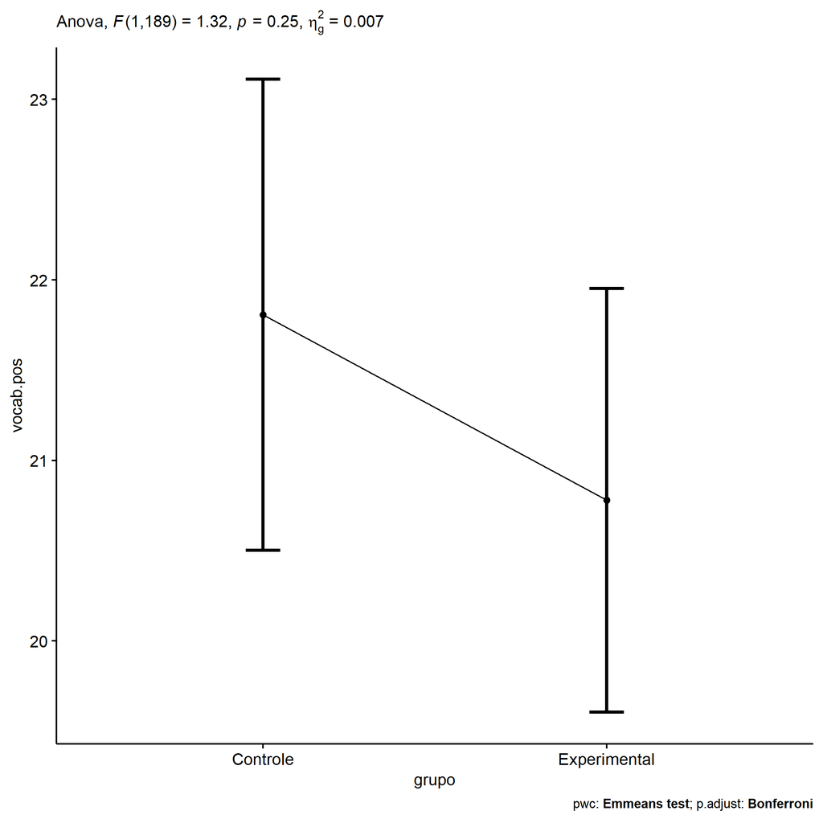

```r
if (!is.null(nrow(plots[["grupo"]]$data)))
  plots[["grupo"]] + ggplot2::scale_color_manual(values = color[["grupo"]])
```

```r
plots <- oneWayAncovaBoxPlots(
  wdat, "vocab.pos", "grupo", aov, pwc, covar = "vocab.pre",
  theme = "classic", color = color[["grupo"]],
  subtitle = which(aov$Effect == "grupo"))
```

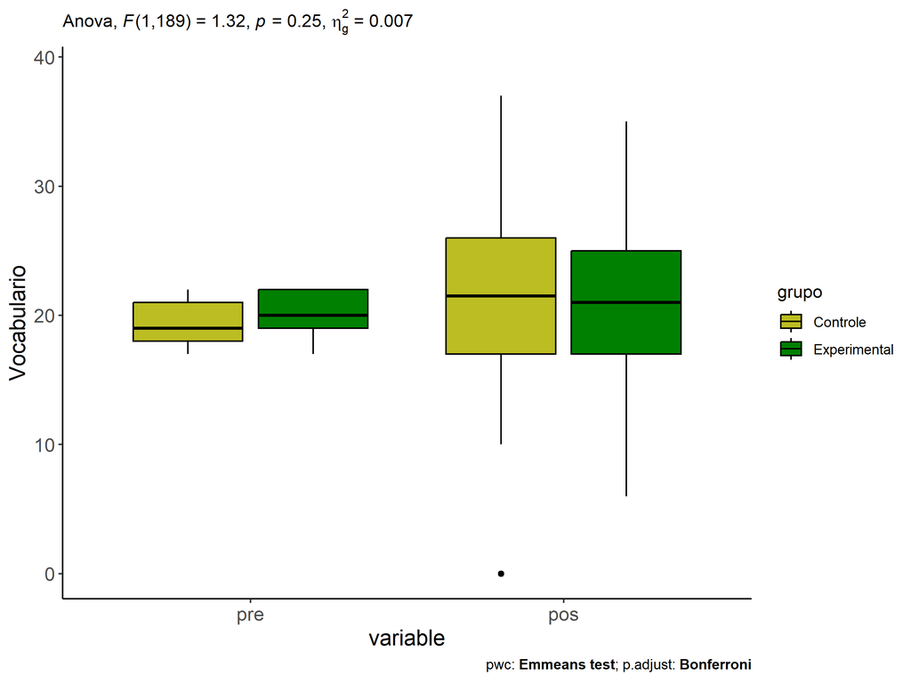

```r
if (length(unique(wdat[["grupo"]])) > 1)
  plots[["grupo"]] + ggplot2::ylab("Vocabulario") + ggplot2::scale_x_discrete(labels=c('pre', 'pos'))
```

```r
if (length(unique(wdat.long[["grupo"]])) > 1)
  plots <- oneWayAncovaBoxPlots(
    wdat.long, "vocab", "grupo", aov, pwc.long, pre.post = "time",
    theme = "classic", color = color$prepost)
```

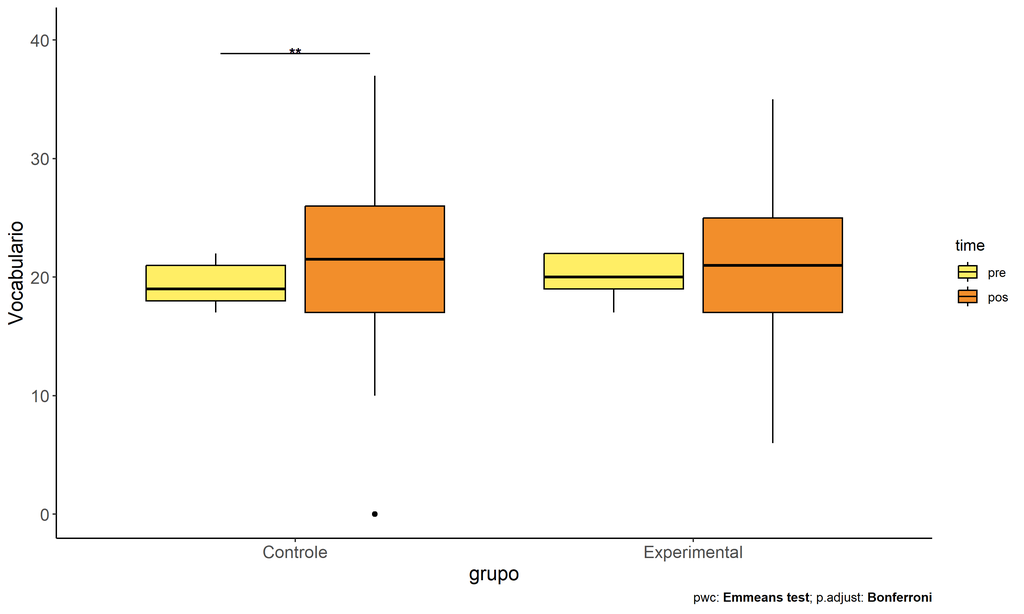

```r
if (length(unique(wdat.long[["grupo"]])) > 1)
  plots[["grupo"]] + ggplot2::ylab("Vocabulario")
```

### Checking linearity assumption

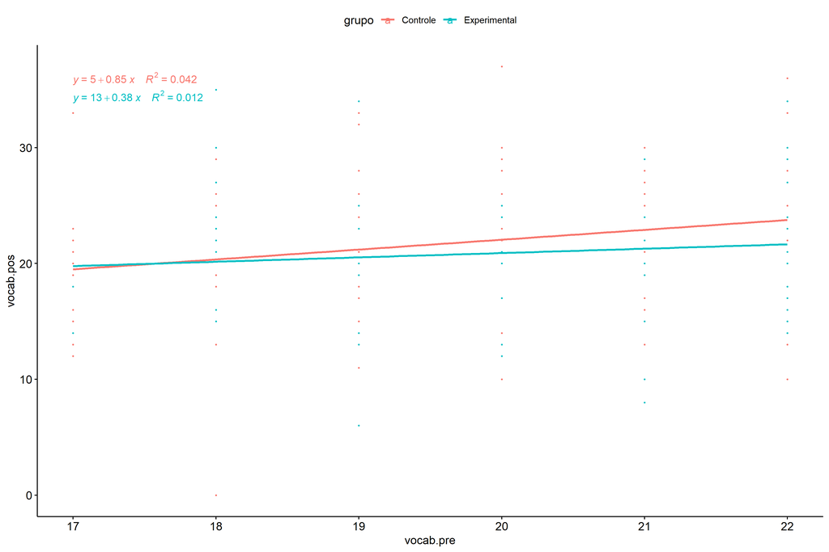

```r
ggscatter(wdat, x = "vocab.pre", y = "vocab.pos", size = 0.5,
          color = "grupo", add = "reg.line")+
  stat_regline_equation(
    aes(label =  paste(..eq.label.., ..rr.label.., sep = "~~~~"), color = grupo)
  )
```

### Checking normality and homogeneity

```r
res <- augment(lm(vocab.pos ~ vocab.pre + grupo, data = wdat))
```

```r
shapiro_test(res$.resid)
```

```
## # A tibble: 1 × 3
##   variable   statistic p.value
##   <chr>          <dbl>   <dbl>
## 1 res$.resid     0.993   0.534
```

```r
levene_test(res, .resid ~ grupo)
```

```
## # A tibble: 1 × 4
##     df1   df2 statistic      p
##   <int> <int>     <dbl>  <dbl>
## 1     1   190      2.95 0.0876
```

# ANCOVA and Pairwise for two factors **grupo:Sexo**

## Without remove non-normal data

```r
pdat = remove_group_data(dat[!is.na(dat[["grupo"]]) & !is.na(dat[["Sexo"]]),], "vocab.pos", c("grupo","Sexo"))

pdat.long <- rbind(pdat[,c("id","grupo","Sexo")], pdat[,c("id","grupo","Sexo")])
pdat.long[["time"]] <- c(rep("pre", nrow(pdat)), rep("pos", nrow(pdat)))
pdat.long[["time"]] <- factor(pdat.long[["time"]], c("pre","pos"))
pdat.long[["vocab"]] <- c(pdat[["vocab.pre"]], pdat[["vocab.pos"]])

aov = anova_test(pdat, vocab.pos ~ vocab.pre + grupo*Sexo)
laov[["grupo:Sexo"]] <- get_anova_table(aov)
```

```r
pwcs <- list()
pwcs[["Sexo"]] <- emmeans_test(
  group_by(pdat, grupo), vocab.pos ~ Sexo,
  covariate = vocab.pre, p.adjust.method = "bonferroni")
pwcs[["grupo"]] <- emmeans_test(
  group_by(pdat, Sexo), vocab.pos ~ grupo,
  covariate = vocab.pre, p.adjust.method = "bonferroni")

pwc <- plyr::rbind.fill(pwcs[["grupo"]], pwcs[["Sexo"]])
pwc <- pwc[,c("grupo","Sexo", colnames(pwc)[!colnames(pwc) %in% c("grupo","Sexo")])]
```

```r
pwc.long <- emmeans_test(dplyr::group_by_at(pdat.long, c("grupo","Sexo")),
                         vocab ~ time,
                         p.adjust.method = "bonferroni")
lpwc[["grupo:Sexo"]] <- plyr::rbind.fill(pwc, pwc.long)
```

```r
ds <- get.descriptives(pdat, "vocab.pos", c("grupo","Sexo"), covar = "vocab.pre")
ds <- merge(ds[ds$variable != "vocab.pre",],
            ds[ds$variable == "vocab.pre", !colnames(ds) %in% c("variable")],
            by = c("grupo","Sexo"), all.x = T, suffixes = c("", ".vocab.pre"))
ds <- merge(get_emmeans(pwcs[["grupo"]]), ds, by = c("grupo","Sexo"), suffixes = c(".emms", ""))
ds <- ds[,c("grupo","Sexo","n","mean.vocab.pre","se.vocab.pre","mean","se","emmean","se.emms")]

colnames(ds) <- c("grupo","Sexo", "N", paste0(c("M","SE")," (pre)"),
                  paste0(c("M","SE"), " (unadj)"), paste0(c("M", "SE"), " (adj)"))

lemms[["grupo:Sexo"]] <- ds
```

## Computing ANCOVA and PairWise After removing non-normal data (OK)

```r
wdat = pdat

res = residuals(lm(vocab.pos ~ vocab.pre + grupo*Sexo, data = wdat))
non.normal = getNonNormal(res, wdat$id, plimit = 0.05)

wdat = wdat[!wdat$id %in% non.normal,]

wdat.long <- rbind(wdat[,c("id","grupo","Sexo")], wdat[,c("id","grupo","Sexo")])
wdat.long[["time"]] <- c(rep("pre", nrow(wdat)), rep("pos", nrow(wdat)))
wdat.long[["time"]] <- factor(wdat.long[["time"]], c("pre","pos"))
wdat.long[["vocab"]] <- c(wdat[["vocab.pre"]], wdat[["vocab.pos"]])


ldat[["grupo:Sexo"]] = wdat

(non.normal)
```

```r
aov = anova_test(wdat, vocab.pos ~ vocab.pre + grupo*Sexo)
laov[["grupo:Sexo"]] <- merge(get_anova_table(aov), laov[["grupo:Sexo"]], by="Effect", suffixes = c("","'"))

(df = get_anova_table(aov))
```

```
## ANOVA Table (type II tests)
##
##       Effect DFn DFd     F     p p<.05   ges
## 1  vocab.pre   1 187 5.321 0.022     * 0.028
## 2      grupo   1 187 1.405 0.237       0.007
## 3       Sexo   1 187 3.814 0.052       0.020
## 4 grupo:Sexo   1 187 1.600 0.207       0.008
```

| Effect | DFn | DFd | F | p | p<.05 | ges |
| --- | --- | --- | --- | --- | --- | --- |
| vocab.pre | 1 | 187 | 5.321 | 0.022 | * | 0.028 |
| grupo | 1 | 187 | 1.405 | 0.237 |  | 0.007 |
| Sexo | 1 | 187 | 3.814 | 0.052 |  | 0.020 |
| grupo:Sexo | 1 | 187 | 1.600 | 0.207 |  | 0.008 |

```r
pwcs <- list()
pwcs[["Sexo"]] <- emmeans_test(
  group_by(wdat, grupo), vocab.pos ~ Sexo,
  covariate = vocab.pre, p.adjust.method = "bonferroni")
pwcs[["grupo"]] <- emmeans_test(
  group_by(wdat, Sexo), vocab.pos ~ grupo,
  covariate = vocab.pre, p.adjust.method = "bonferroni")

pwc <- plyr::rbind.fill(pwcs[["grupo"]], pwcs[["Sexo"]])
pwc <- pwc[,c("grupo","Sexo", colnames(pwc)[!colnames(pwc) %in% c("grupo","Sexo")])]
```

| grupo | Sexo | term | .y. | group1 | group2 | df | statistic | p | p.adj | p.adj.signif |
| --- | --- | --- | --- | --- | --- | --- | --- | --- | --- | --- |
|  | F | vocab.pre*grupo | vocab.pos | Controle | Experimental | 187 | -0.114 | 0.910 | 0.910 | ns |
|  | M | vocab.pre*grupo | vocab.pos | Controle | Experimental | 187 | 1.728 | 0.086 | 0.086 | ns |
| Controle |  | vocab.pre*Sexo | vocab.pos | F | M | 187 | 0.366 | 0.714 | 0.714 | ns |
| Experimental |  | vocab.pre*Sexo | vocab.pos | F | M | 187 | 2.298 | 0.023 | 0.023 | * |

```r
pwc.long <- emmeans_test(dplyr::group_by_at(wdat.long, c("grupo","Sexo")),
                         vocab ~ time,
                         p.adjust.method = "bonferroni")
lpwc[["grupo:Sexo"]] <- merge(plyr::rbind.fill(pwc, pwc.long), lpwc[["grupo:Sexo"]], by=c("grupo","Sexo","term",".y.","group1","group2"), suffixes = c("","'"))
```

| grupo | Sexo | term | .y. | group1 | group2 | df | statistic | p | p.adj | p.adj.signif |
| --- | --- | --- | --- | --- | --- | --- | --- | --- | --- | --- |
| Controle | F | time | vocab | pre | pos | 376 | -2.356 | 0.019 | 0.019 | * |
| Controle | M | time | vocab | pre | pos | 376 | -2.076 | 0.039 | 0.039 | * |
| Experimental | F | time | vocab | pre | pos | 376 | -2.621 | 0.009 | 0.009 | ** |
| Experimental | M | time | vocab | pre | pos | 376 | 0.503 | 0.615 | 0.615 | ns |

```r
ds <- get.descriptives(wdat, "vocab.pos", c("grupo","Sexo"), covar = "vocab.pre")
ds <- merge(ds[ds$variable != "vocab.pre",],
            ds[ds$variable == "vocab.pre", !colnames(ds) %in% c("variable")],
            by = c("grupo","Sexo"), all.x = T, suffixes = c("", ".vocab.pre"))
ds <- merge(get_emmeans(pwcs[["grupo"]]), ds, by = c("grupo","Sexo"), suffixes = c(".emms", ""))
ds <- ds[,c("grupo","Sexo","n","mean.vocab.pre","se.vocab.pre","mean","se","emmean","se.emms")]

colnames(ds) <- c("grupo","Sexo", "N", paste0(c("M","SE")," (pre)"),
                  paste0(c("M","SE"), " (unadj)"), paste0(c("M", "SE"), " (adj)"))

lemms[["grupo:Sexo"]] <- merge(ds, lemms[["grupo:Sexo"]], by=c("grupo","Sexo"), suffixes = c("","'"))
```

| grupo | Sexo | N | M (pre) | SE (pre) | M (unadj) | SE (unadj) | M (adj) | SE (adj) |
| --- | --- | --- | --- | --- | --- | --- | --- | --- |
| Controle | F | 39 | 19.513 | 0.259 | 21.897 | 0.991 | 22.078 | 0.969 |
| Controle | M | 47 | 19.489 | 0.241 | 21.404 | 1.058 | 21.599 | 0.884 |
| Experimental | F | 49 | 19.939 | 0.239 | 22.306 | 0.713 | 22.226 | 0.862 |
| Experimental | M | 57 | 20.158 | 0.221 | 19.737 | 0.777 | 19.522 | 0.804 |

### Plots for ancova

```r
plots <- twoWayAncovaPlots(
  wdat, "vocab.pos", c("grupo","Sexo"), aov, pwcs, addParam = c("mean_se"),
  font.label.size=10, step.increase=0.05, p.label="p.adj",
  subtitle = which(aov$Effect == "grupo:Sexo"))
```

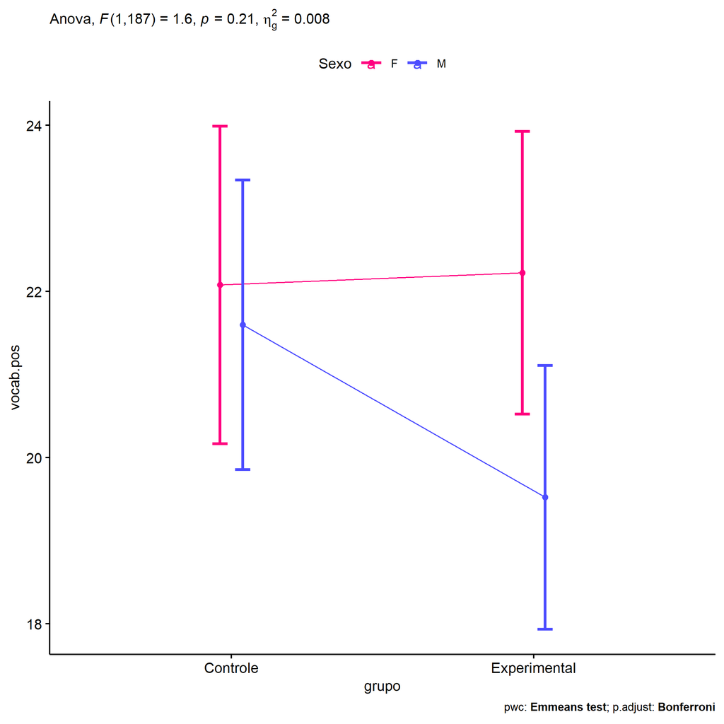

```r
if (!is.null(plots[["grupo"]]))
  plots[["grupo"]] + ggplot2::scale_color_manual(values = color[["Sexo"]])
```

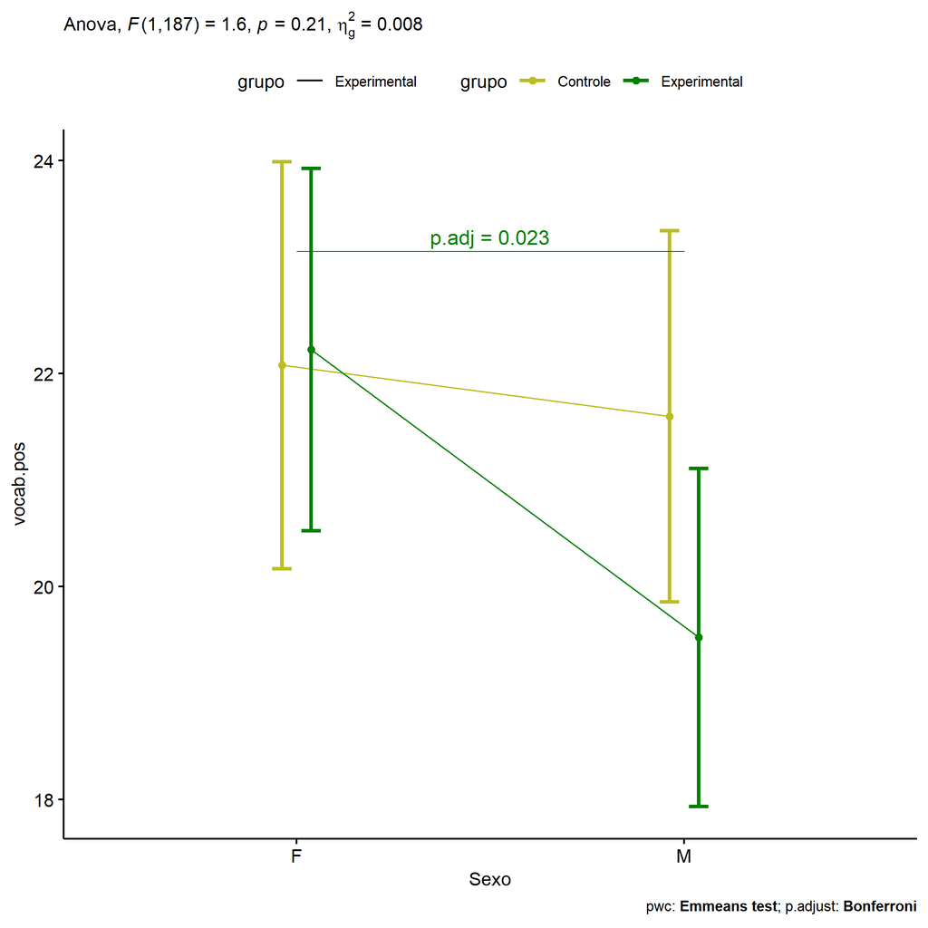

```r
if (!is.null(plots[["Sexo"]]))
  plots[["Sexo"]] + ggplot2::scale_color_manual(values = color[["grupo"]])
```

```r
plots <- twoWayAncovaBoxPlots(
  wdat, "vocab.pos", c("grupo","Sexo"), aov, pwcs, covar = "vocab.pre",
  theme = "classic", color = color[["grupo:Sexo"]],
  subtitle = which(aov$Effect == "grupo:Sexo"))
```

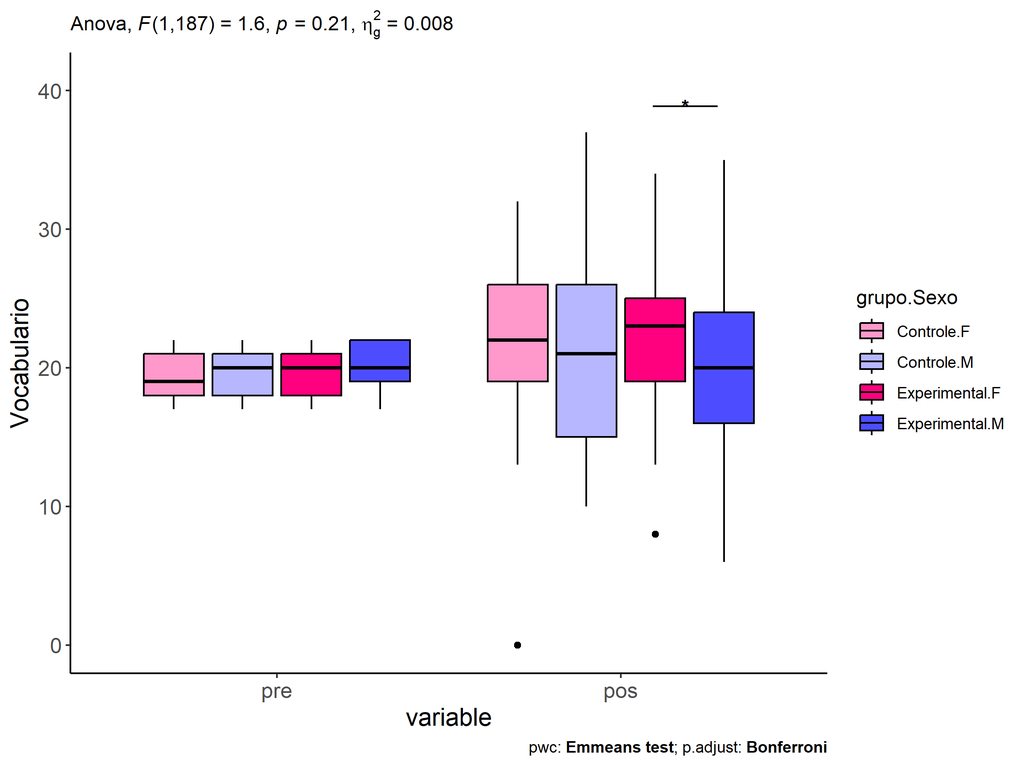

```r
plots[["grupo:Sexo"]] + ggplot2::ylab("Vocabulario") + ggplot2::scale_x_discrete(labels=c('pre', 'pos'))
```

```r
plots <- twoWayAncovaBoxPlots(
  wdat.long, "vocab", c("grupo","Sexo"), aov, pwc.long, pre.post = "time",
  theme = "classic", color = color$prepost)
```

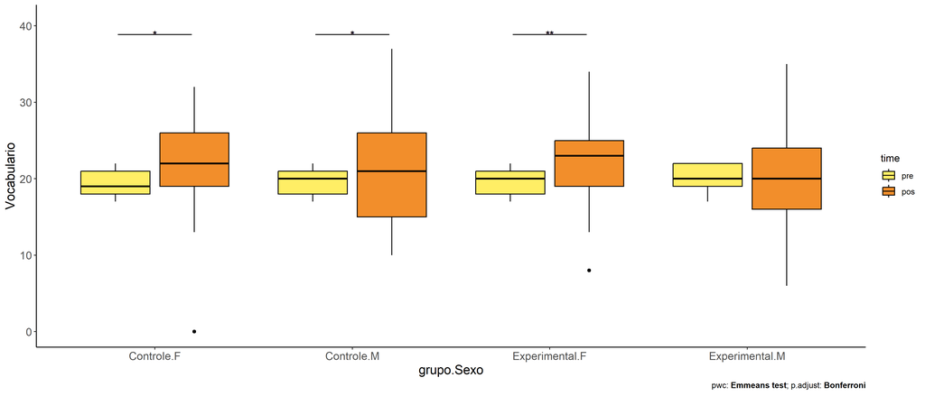

```r
plots[["grupo:Sexo"]] + ggplot2::ylab("Vocabulario")
```

### Checking linearity assumption

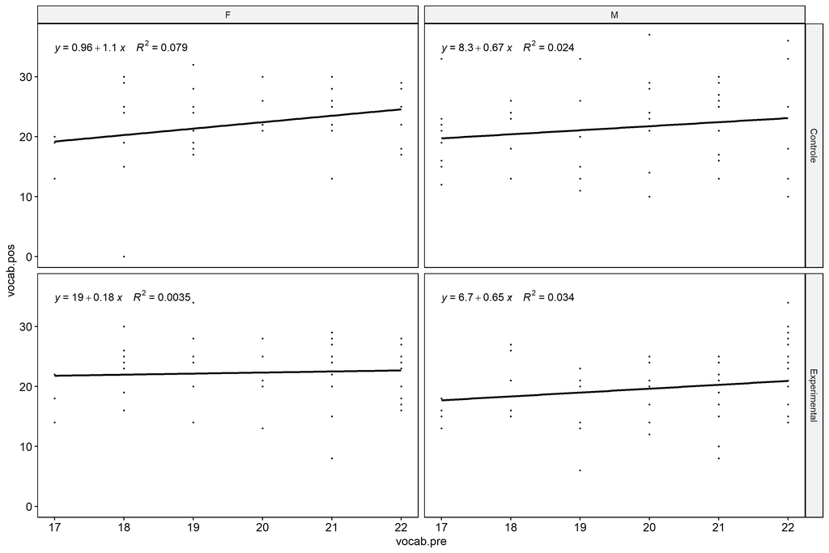

```r
ggscatter(wdat, x = "vocab.pre", y = "vocab.pos", size = 0.5,
          facet.by = c("grupo","Sexo"), add = "reg.line")+
  stat_regline_equation(
    aes(label =  paste(..eq.label.., ..rr.label.., sep = "~~~~"))
  )
```

### Checking normality and homogeneity

```r
res <- augment(lm(vocab.pos ~ vocab.pre + grupo*Sexo, data = wdat))
```

```r
shapiro_test(res$.resid)
```

```
## # A tibble: 1 × 3
##   variable   statistic p.value
##   <chr>          <dbl>   <dbl>
## 1 res$.resid     0.995   0.798
```

```r
levene_test(res, .resid ~ grupo*Sexo)
```

```
## # A tibble: 1 × 4
##     df1   df2 statistic      p
##   <int> <int>     <dbl>  <dbl>
## 1     3   188      2.77 0.0429
```

# ANCOVA and Pairwise for two factors **grupo:Zona**

## Without remove non-normal data

```r
pdat = remove_group_data(dat[!is.na(dat[["grupo"]]) & !is.na(dat[["Zona"]]),], "vocab.pos", c("grupo","Zona"))

pdat.long <- rbind(pdat[,c("id","grupo","Zona")], pdat[,c("id","grupo","Zona")])
pdat.long[["time"]] <- c(rep("pre", nrow(pdat)), rep("pos", nrow(pdat)))
pdat.long[["time"]] <- factor(pdat.long[["time"]], c("pre","pos"))
pdat.long[["vocab"]] <- c(pdat[["vocab.pre"]], pdat[["vocab.pos"]])

aov = anova_test(pdat, vocab.pos ~ vocab.pre + grupo*Zona)
laov[["grupo:Zona"]] <- get_anova_table(aov)
```

```r
pwcs <- list()
pwcs[["Zona"]] <- emmeans_test(
  group_by(pdat, grupo), vocab.pos ~ Zona,
  covariate = vocab.pre, p.adjust.method = "bonferroni")
pwcs[["grupo"]] <- emmeans_test(
  group_by(pdat, Zona), vocab.pos ~ grupo,
  covariate = vocab.pre, p.adjust.method = "bonferroni")

pwc <- plyr::rbind.fill(pwcs[["grupo"]], pwcs[["Zona"]])
pwc <- pwc[,c("grupo","Zona", colnames(pwc)[!colnames(pwc) %in% c("grupo","Zona")])]
```

```r
pwc.long <- emmeans_test(dplyr::group_by_at(pdat.long, c("grupo","Zona")),
                         vocab ~ time,
                         p.adjust.method = "bonferroni")
lpwc[["grupo:Zona"]] <- plyr::rbind.fill(pwc, pwc.long)
```

```r
ds <- get.descriptives(pdat, "vocab.pos", c("grupo","Zona"), covar = "vocab.pre")
ds <- merge(ds[ds$variable != "vocab.pre",],
            ds[ds$variable == "vocab.pre", !colnames(ds) %in% c("variable")],
            by = c("grupo","Zona"), all.x = T, suffixes = c("", ".vocab.pre"))
ds <- merge(get_emmeans(pwcs[["grupo"]]), ds, by = c("grupo","Zona"), suffixes = c(".emms", ""))
ds <- ds[,c("grupo","Zona","n","mean.vocab.pre","se.vocab.pre","mean","se","emmean","se.emms")]

colnames(ds) <- c("grupo","Zona", "N", paste0(c("M","SE")," (pre)"),
                  paste0(c("M","SE"), " (unadj)"), paste0(c("M", "SE"), " (adj)"))

lemms[["grupo:Zona"]] <- ds
```

## Computing ANCOVA and PairWise After removing non-normal data (OK)

```r
wdat = pdat

res = residuals(lm(vocab.pos ~ vocab.pre + grupo*Zona, data = wdat))
non.normal = getNonNormal(res, wdat$id, plimit = 0.05)

wdat = wdat[!wdat$id %in% non.normal,]

wdat.long <- rbind(wdat[,c("id","grupo","Zona")], wdat[,c("id","grupo","Zona")])
wdat.long[["time"]] <- c(rep("pre", nrow(wdat)), rep("pos", nrow(wdat)))
wdat.long[["time"]] <- factor(wdat.long[["time"]], c("pre","pos"))
wdat.long[["vocab"]] <- c(wdat[["vocab.pre"]], wdat[["vocab.pos"]])


ldat[["grupo:Zona"]] = wdat

(non.normal)
```

```r
aov = anova_test(wdat, vocab.pos ~ vocab.pre + grupo*Zona)
laov[["grupo:Zona"]] <- merge(get_anova_table(aov), laov[["grupo:Zona"]], by="Effect", suffixes = c("","'"))

(df = get_anova_table(aov))
```

```
## ANOVA Table (type II tests)
##
##       Effect DFn DFd     F     p p<.05      ges
## 1  vocab.pre   1 136 5.737 0.018     * 4.00e-02
## 2      grupo   1 136 3.879 0.051       2.80e-02
## 3       Zona   1 136 0.343 0.559       3.00e-03
## 4 grupo:Zona   1 136 0.007 0.935       4.84e-05
```

| Effect | DFn | DFd | F | p | p<.05 | ges |
| --- | --- | --- | --- | --- | --- | --- |
| vocab.pre | 1 | 136 | 5.737 | 0.018 | * | 0.040 |
| grupo | 1 | 136 | 3.879 | 0.051 |  | 0.028 |
| Zona | 1 | 136 | 0.343 | 0.559 |  | 0.003 |
| grupo:Zona | 1 | 136 | 0.007 | 0.935 |  | 0.000 |

```r
pwcs <- list()
pwcs[["Zona"]] <- emmeans_test(
  group_by(wdat, grupo), vocab.pos ~ Zona,
  covariate = vocab.pre, p.adjust.method = "bonferroni")
pwcs[["grupo"]] <- emmeans_test(
  group_by(wdat, Zona), vocab.pos ~ grupo,
  covariate = vocab.pre, p.adjust.method = "bonferroni")

pwc <- plyr::rbind.fill(pwcs[["grupo"]], pwcs[["Zona"]])
pwc <- pwc[,c("grupo","Zona", colnames(pwc)[!colnames(pwc) %in% c("grupo","Zona")])]
```

| grupo | Zona | term | .y. | group1 | group2 | df | statistic | p | p.adj | p.adj.signif |
| --- | --- | --- | --- | --- | --- | --- | --- | --- | --- | --- |
|  | Rural | vocab.pre*grupo | vocab.pos | Controle | Experimental | 136 | 1.521 | 0.130 | 0.130 | ns |
|  | Urbana | vocab.pre*grupo | vocab.pos | Controle | Experimental | 136 | 1.249 | 0.214 | 0.214 | ns |
| Controle |  | vocab.pre*Zona | vocab.pos | Rural | Urbana | 136 | -0.453 | 0.651 | 0.651 | ns |
| Experimental |  | vocab.pre*Zona | vocab.pos | Rural | Urbana | 136 | -0.378 | 0.706 | 0.706 | ns |

```r
pwc.long <- emmeans_test(dplyr::group_by_at(wdat.long, c("grupo","Zona")),
                         vocab ~ time,
                         p.adjust.method = "bonferroni")
lpwc[["grupo:Zona"]] <- merge(plyr::rbind.fill(pwc, pwc.long), lpwc[["grupo:Zona"]], by=c("grupo","Zona","term",".y.","group1","group2"), suffixes = c("","'"))
```

| grupo | Zona | term | .y. | group1 | group2 | df | statistic | p | p.adj | p.adj.signif |
| --- | --- | --- | --- | --- | --- | --- | --- | --- | --- | --- |
| Controle | Rural | time | vocab | pre | pos | 274 | -2.914 | 0.004 | 0.004 | ** |
| Controle | Urbana | time | vocab | pre | pos | 274 | -2.547 | 0.011 | 0.011 | * |
| Experimental | Rural | time | vocab | pre | pos | 274 | -0.768 | 0.443 | 0.443 | ns |
| Experimental | Urbana | time | vocab | pre | pos | 274 | -1.045 | 0.297 | 0.297 | ns |

```r
ds <- get.descriptives(wdat, "vocab.pos", c("grupo","Zona"), covar = "vocab.pre")
ds <- merge(ds[ds$variable != "vocab.pre",],
            ds[ds$variable == "vocab.pre", !colnames(ds) %in% c("variable")],
            by = c("grupo","Zona"), all.x = T, suffixes = c("", ".vocab.pre"))
ds <- merge(get_emmeans(pwcs[["grupo"]]), ds, by = c("grupo","Zona"), suffixes = c(".emms", ""))
ds <- ds[,c("grupo","Zona","n","mean.vocab.pre","se.vocab.pre","mean","se","emmean","se.emms")]

colnames(ds) <- c("grupo","Zona", "N", paste0(c("M","SE")," (pre)"),
                  paste0(c("M","SE"), " (unadj)"), paste0(c("M", "SE"), " (adj)"))

lemms[["grupo:Zona"]] <- merge(ds, lemms[["grupo:Zona"]], by=c("grupo","Zona"), suffixes = c("","'"))
```

| grupo | Zona | N | M (pre) | SE (pre) | M (unadj) | SE (unadj) | M (adj) | SE (adj) |
| --- | --- | --- | --- | --- | --- | --- | --- | --- |
| Controle | Rural | 41 | 19.366 | 0.265 | 22.049 | 1.067 | 22.380 | 0.879 |
| Controle | Urbana | 23 | 20.043 | 0.330 | 23.174 | 0.879 | 23.042 | 1.160 |
| Experimental | Rural | 50 | 20.100 | 0.239 | 20.740 | 0.727 | 20.570 | 0.789 |
| Experimental | Urbana | 27 | 19.963 | 0.313 | 21.148 | 1.086 | 21.072 | 1.070 |

### Plots for ancova

```r
plots <- twoWayAncovaPlots(
  wdat, "vocab.pos", c("grupo","Zona"), aov, pwcs, addParam = c("mean_se"),
  font.label.size=10, step.increase=0.05, p.label="p.adj",
  subtitle = which(aov$Effect == "grupo:Zona"))
```

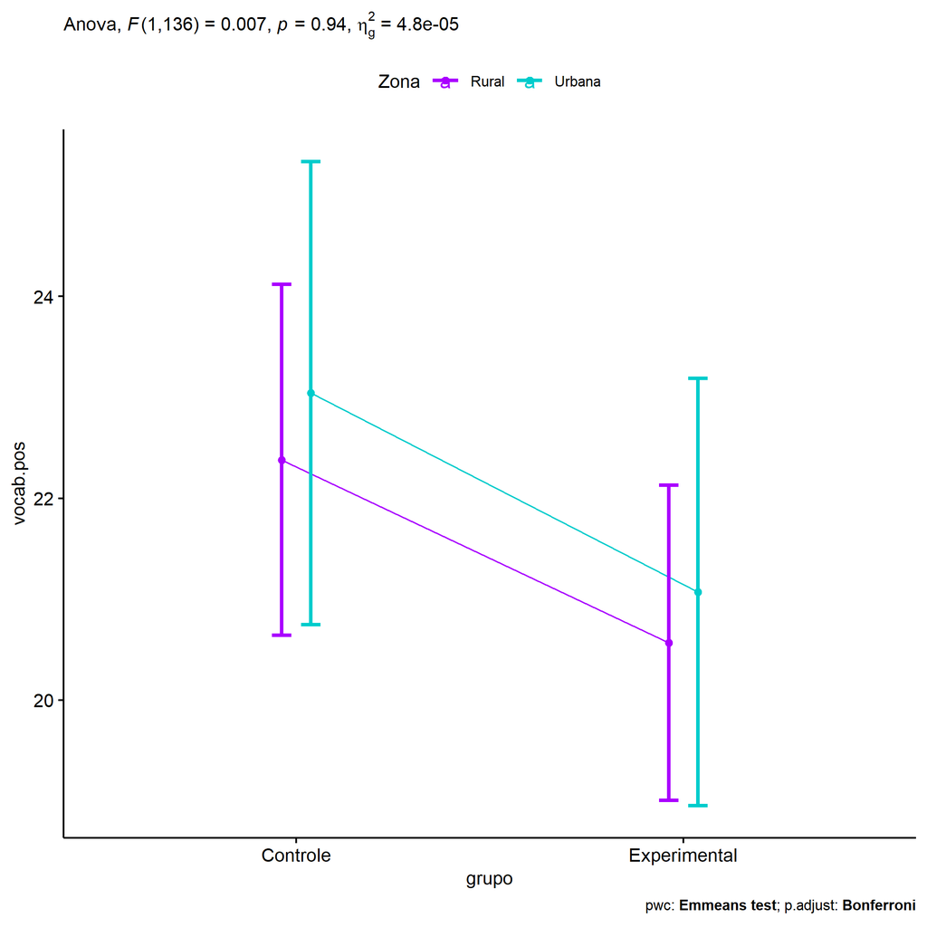

```r
if (!is.null(plots[["grupo"]]))
  plots[["grupo"]] + ggplot2::scale_color_manual(values = color[["Zona"]])
```

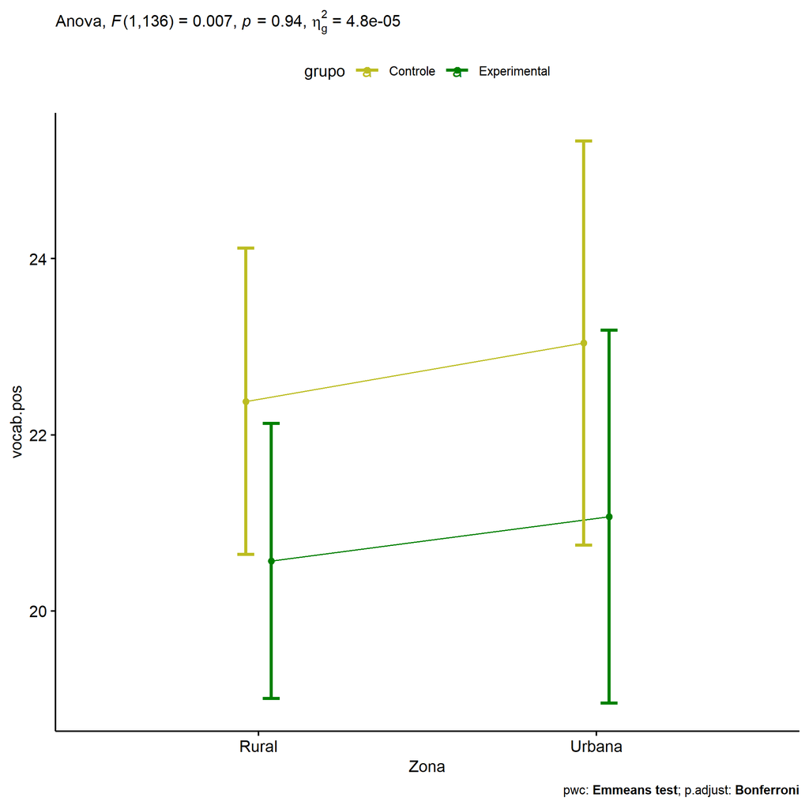

```r
if (!is.null(plots[["Zona"]]))
  plots[["Zona"]] + ggplot2::scale_color_manual(values = color[["grupo"]])
```

```r
plots <- twoWayAncovaBoxPlots(
  wdat, "vocab.pos", c("grupo","Zona"), aov, pwcs, covar = "vocab.pre",
  theme = "classic", color = color[["grupo:Zona"]],
  subtitle = which(aov$Effect == "grupo:Zona"))
```

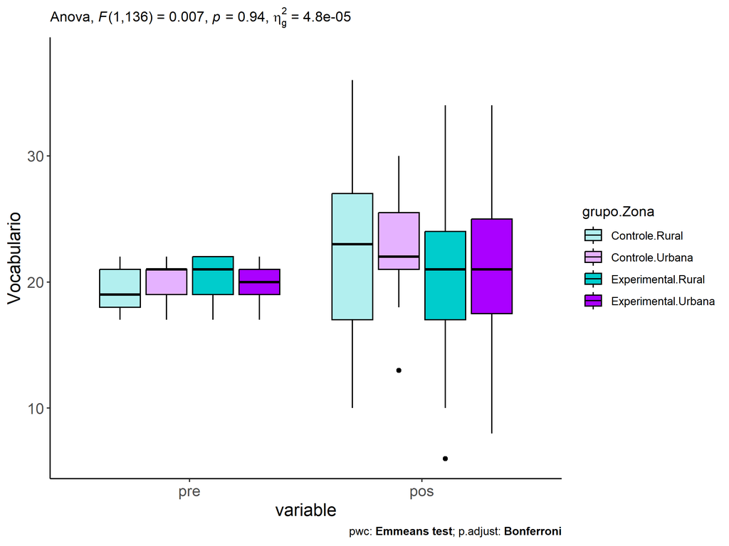

```r
plots[["grupo:Zona"]] + ggplot2::ylab("Vocabulario") + ggplot2::scale_x_discrete(labels=c('pre', 'pos'))
```

```r
plots <- twoWayAncovaBoxPlots(
  wdat.long, "vocab", c("grupo","Zona"), aov, pwc.long, pre.post = "time",
  theme = "classic", color = color$prepost)
```

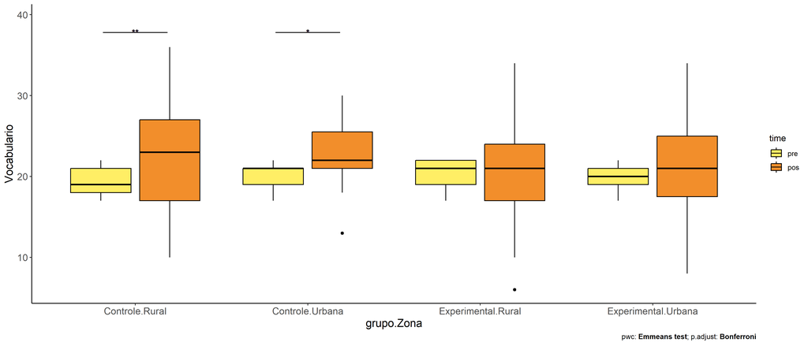

```r
plots[["grupo:Zona"]] + ggplot2::ylab("Vocabulario")
```

### Checking linearity assumption

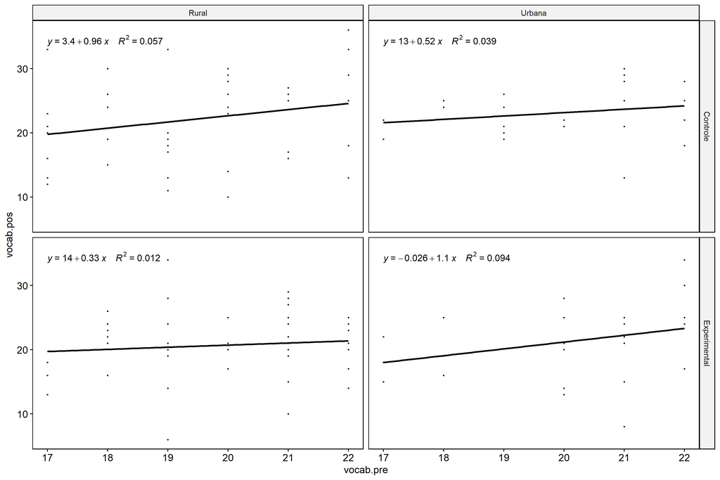

```r
ggscatter(wdat, x = "vocab.pre", y = "vocab.pos", size = 0.5,
          facet.by = c("grupo","Zona"), add = "reg.line")+
  stat_regline_equation(
    aes(label =  paste(..eq.label.., ..rr.label.., sep = "~~~~"))
  )
```

### Checking normality and homogeneity

```r
res <- augment(lm(vocab.pos ~ vocab.pre + grupo*Zona, data = wdat))
```

```r
shapiro_test(res$.resid)
```

```
## # A tibble: 1 × 3
##   variable   statistic p.value
##   <chr>          <dbl>   <dbl>
## 1 res$.resid     0.993   0.674
```

```r
levene_test(res, .resid ~ grupo*Zona)
```

```
## # A tibble: 1 × 4
##     df1   df2 statistic      p
##   <int> <int>     <dbl>  <dbl>
## 1     3   137      2.66 0.0504
```

# ANCOVA and Pairwise for two factors **grupo:Cor.Raca**

## Without remove non-normal data

```r
pdat = remove_group_data(dat[!is.na(dat[["grupo"]]) & !is.na(dat[["Cor.Raca"]]),], "vocab.pos", c("grupo","Cor.Raca"))
pdat.long <- rbind(pdat[,c("id","grupo","Cor.Raca")], pdat[,c("id","grupo","Cor.Raca")])
pdat.long[["time"]] <- c(rep("pre", nrow(pdat)), rep("pos", nrow(pdat)))
pdat.long[["time"]] <- factor(pdat.long[["time"]], c("pre","pos"))
pdat.long[["vocab"]] <- c(pdat[["vocab.pre"]], pdat[["vocab.pos"]])

aov = anova_test(pdat, vocab.pos ~ vocab.pre + grupo*Cor.Raca)
laov[["grupo:Cor.Raca"]] <- get_anova_table(aov)
```

```r
pwcs <- list()
pwcs[["Cor.Raca"]] <- emmeans_test(
  group_by(pdat, grupo), vocab.pos ~ Cor.Raca,
  covariate = vocab.pre, p.adjust.method = "bonferroni")
pwcs[["grupo"]] <- emmeans_test(
  group_by(pdat, Cor.Raca), vocab.pos ~ grupo,
  covariate = vocab.pre, p.adjust.method = "bonferroni")

pwc <- plyr::rbind.fill(pwcs[["grupo"]], pwcs[["Cor.Raca"]])
pwc <- pwc[,c("grupo","Cor.Raca", colnames(pwc)[!colnames(pwc) %in% c("grupo","Cor.Raca")])]
```

```r
pwc.long <- emmeans_test(dplyr::group_by_at(pdat.long, c("grupo","Cor.Raca")),
                         vocab ~ time,
                         p.adjust.method = "bonferroni")
lpwc[["grupo:Cor.Raca"]] <- plyr::rbind.fill(pwc, pwc.long)
```

```r
ds <- get.descriptives(pdat, "vocab.pos", c("grupo","Cor.Raca"), covar = "vocab.pre")
ds <- merge(ds[ds$variable != "vocab.pre",],
            ds[ds$variable == "vocab.pre", !colnames(ds) %in% c("variable")],
            by = c("grupo","Cor.Raca"), all.x = T, suffixes = c("", ".vocab.pre"))
ds <- merge(get_emmeans(pwcs[["grupo"]]), ds, by = c("grupo","Cor.Raca"), suffixes = c(".emms", ""))
ds <- ds[,c("grupo","Cor.Raca","n","mean.vocab.pre","se.vocab.pre","mean","se","emmean","se.emms")]

colnames(ds) <- c("grupo","Cor.Raca", "N", paste0(c("M","SE")," (pre)"),
                  paste0(c("M","SE"), " (unadj)"), paste0(c("M", "SE"), " (adj)"))

lemms[["grupo:Cor.Raca"]] <- ds
```

## Computing ANCOVA and PairWise After removing non-normal data (OK)

```r
wdat = pdat

res = residuals(lm(vocab.pos ~ vocab.pre + grupo*Cor.Raca, data = wdat))
non.normal = getNonNormal(res, wdat$id, plimit = 0.05)

wdat = wdat[!wdat$id %in% non.normal,]

wdat.long <- rbind(wdat[,c("id","grupo","Cor.Raca")], wdat[,c("id","grupo","Cor.Raca")])
wdat.long[["time"]] <- c(rep("pre", nrow(wdat)), rep("pos", nrow(wdat)))
wdat.long[["time"]] <- factor(wdat.long[["time"]], c("pre","pos"))
wdat.long[["vocab"]] <- c(wdat[["vocab.pre"]], wdat[["vocab.pos"]])


ldat[["grupo:Cor.Raca"]] = wdat

(non.normal)
```

```r
aov = anova_test(wdat, vocab.pos ~ vocab.pre + grupo*Cor.Raca)
laov[["grupo:Cor.Raca"]] <- merge(get_anova_table(aov), laov[["grupo:Cor.Raca"]], by="Effect", suffixes = c("","'"))

(df = get_anova_table(aov))
```

```
## ANOVA Table (type II tests)
##
##           Effect DFn DFd     F     p p<.05   ges
## 1      vocab.pre   1  82 7.091 0.009     * 0.080
## 2          grupo   1  82 1.393 0.241       0.017
## 3       Cor.Raca   1  82 2.154 0.146       0.026
## 4 grupo:Cor.Raca   1  82 3.655 0.059       0.043
```

| Effect | DFn | DFd | F | p | p<.05 | ges |
| --- | --- | --- | --- | --- | --- | --- |
| vocab.pre | 1 | 82 | 7.091 | 0.009 | * | 0.080 |
| grupo | 1 | 82 | 1.393 | 0.241 |  | 0.017 |
| Cor.Raca | 1 | 82 | 2.154 | 0.146 |  | 0.026 |
| grupo:Cor.Raca | 1 | 82 | 3.655 | 0.059 |  | 0.043 |

```r
pwcs <- list()
pwcs[["Cor.Raca"]] <- emmeans_test(
  group_by(wdat, grupo), vocab.pos ~ Cor.Raca,
  covariate = vocab.pre, p.adjust.method = "bonferroni")
pwcs[["grupo"]] <- emmeans_test(
  group_by(wdat, Cor.Raca), vocab.pos ~ grupo,
  covariate = vocab.pre, p.adjust.method = "bonferroni")

pwc <- plyr::rbind.fill(pwcs[["grupo"]], pwcs[["Cor.Raca"]])
pwc <- pwc[,c("grupo","Cor.Raca", colnames(pwc)[!colnames(pwc) %in% c("grupo","Cor.Raca")])]
```

| grupo | Cor.Raca | term | .y. | group1 | group2 | df | statistic | p | p.adj | p.adj.signif |
| --- | --- | --- | --- | --- | --- | --- | --- | --- | --- | --- |
|  | Branca | vocab.pre*grupo | vocab.pos | Controle | Experimental | 82 | 2.240 | 0.028 | 0.028 | * |
|  | Parda | vocab.pre*grupo | vocab.pos | Controle | Experimental | 82 | 0.177 | 0.860 | 0.860 | ns |
| Controle |  | vocab.pre*Cor.Raca | vocab.pos | Branca | Parda | 82 | 0.080 | 0.936 | 0.936 | ns |
| Experimental |  | vocab.pre*Cor.Raca | vocab.pos | Branca | Parda | 82 | -2.409 | 0.018 | 0.018 | * |

```r
pwc.long <- emmeans_test(dplyr::group_by_at(wdat.long, c("grupo","Cor.Raca")),
                         vocab ~ time,
                         p.adjust.method = "bonferroni")
lpwc[["grupo:Cor.Raca"]] <- merge(plyr::rbind.fill(pwc, pwc.long), lpwc[["grupo:Cor.Raca"]], by=c("grupo","Cor.Raca","term",".y.","group1","group2"), suffixes = c("","'"))
```

| grupo | Cor.Raca | term | .y. | group1 | group2 | df | statistic | p | p.adj | p.adj.signif |
| --- | --- | --- | --- | --- | --- | --- | --- | --- | --- | --- |
| Controle | Branca | time | vocab | pre | pos | 166 | -1.224 | 0.223 | 0.223 | ns |
| Controle | Parda | time | vocab | pre | pos | 166 | -1.809 | 0.072 | 0.072 | ns |
| Experimental | Branca | time | vocab | pre | pos | 166 | 1.713 | 0.089 | 0.089 | ns |
| Experimental | Parda | time | vocab | pre | pos | 166 | -1.706 | 0.090 | 0.090 | ns |

```r
ds <- get.descriptives(wdat, "vocab.pos", c("grupo","Cor.Raca"), covar = "vocab.pre")
ds <- merge(ds[ds$variable != "vocab.pre",],
            ds[ds$variable == "vocab.pre", !colnames(ds) %in% c("variable")],
            by = c("grupo","Cor.Raca"), all.x = T, suffixes = c("", ".vocab.pre"))
ds <- merge(get_emmeans(pwcs[["grupo"]]), ds, by = c("grupo","Cor.Raca"), suffixes = c(".emms", ""))
ds <- ds[,c("grupo","Cor.Raca","n","mean.vocab.pre","se.vocab.pre","mean","se","emmean","se.emms")]

colnames(ds) <- c("grupo","Cor.Raca", "N", paste0(c("M","SE")," (pre)"),
                  paste0(c("M","SE"), " (unadj)"), paste0(c("M", "SE"), " (adj)"))

lemms[["grupo:Cor.Raca"]] <- merge(ds, lemms[["grupo:Cor.Raca"]], by=c("grupo","Cor.Raca"), suffixes = c("","'"))
```

| grupo | Cor.Raca | N | M (pre) | SE (pre) | M (unadj) | SE (unadj) | M (adj) | SE (adj) |
| --- | --- | --- | --- | --- | --- | --- | --- | --- |
| Controle | Branca | 12 | 20.167 | 0.490 | 22.583 | 1.928 | 22.317 | 1.852 |
| Controle | Parda | 32 | 19.750 | 0.288 | 21.938 | 1.409 | 22.142 | 1.135 |
| Experimental | Branca | 7 | 20.000 | 0.617 | 15.571 | 1.824 | 15.493 | 2.421 |
| Experimental | Parda | 36 | 20.000 | 0.279 | 21.944 | 0.915 | 21.866 | 1.068 |

### Plots for ancova

```r
plots <- twoWayAncovaPlots(
  wdat, "vocab.pos", c("grupo","Cor.Raca"), aov, pwcs, addParam = c("mean_se"),
  font.label.size=10, step.increase=0.05, p.label="p.adj",
  subtitle = which(aov$Effect == "grupo:Cor.Raca"))
```

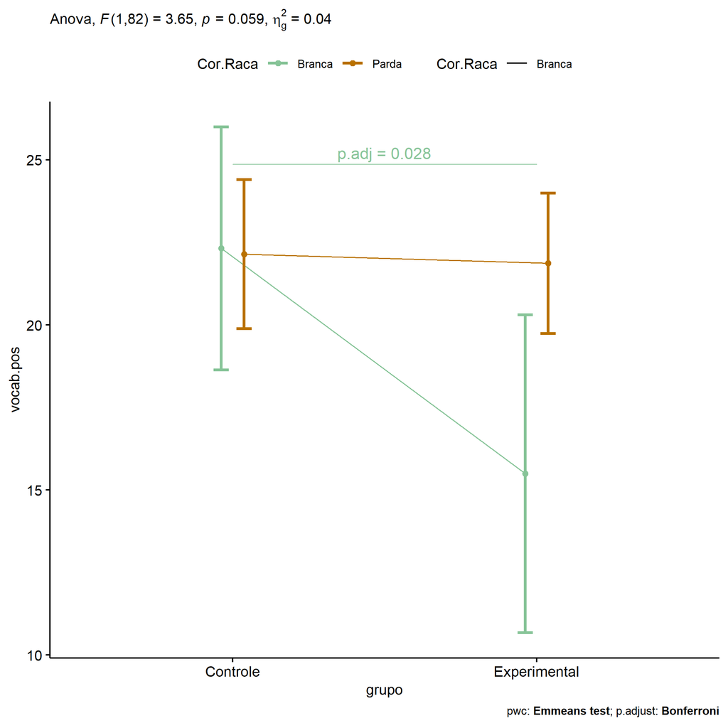

```r
if (!is.null(plots[["grupo"]]))
  plots[["grupo"]] + ggplot2::scale_color_manual(values = color[["Cor.Raca"]])
```

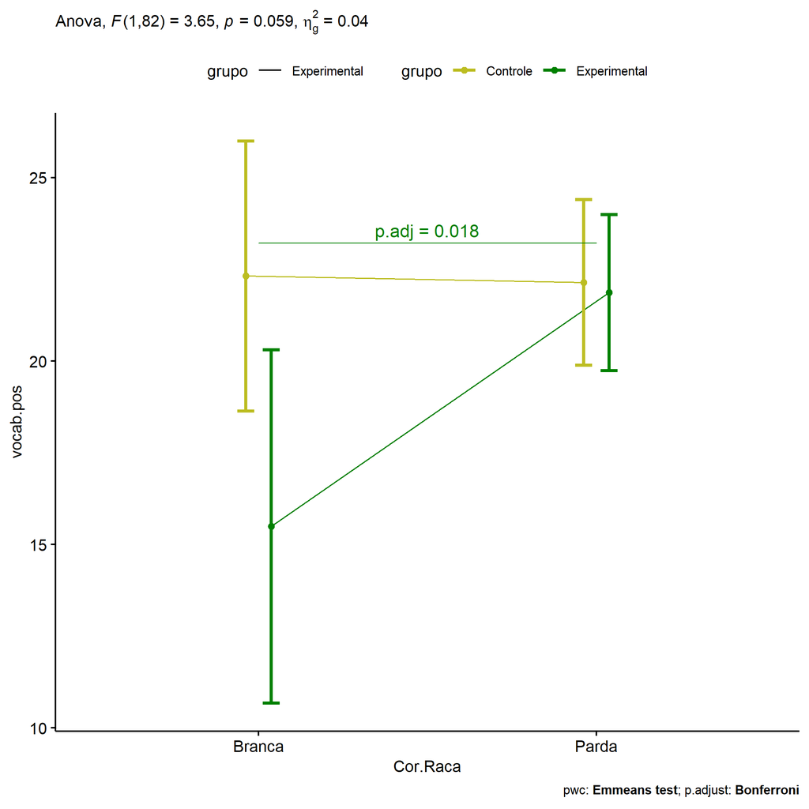

```r
if (!is.null(plots[["Cor.Raca"]]))
  plots[["Cor.Raca"]] + ggplot2::scale_color_manual(values = color[["grupo"]])
```

```r
plots <- twoWayAncovaBoxPlots(
  wdat, "vocab.pos", c("grupo","Cor.Raca"), aov, pwcs, covar = "vocab.pre",
  theme = "classic", color = color[["grupo:Cor.Raca"]],
  subtitle = which(aov$Effect == "grupo:Cor.Raca"))
```

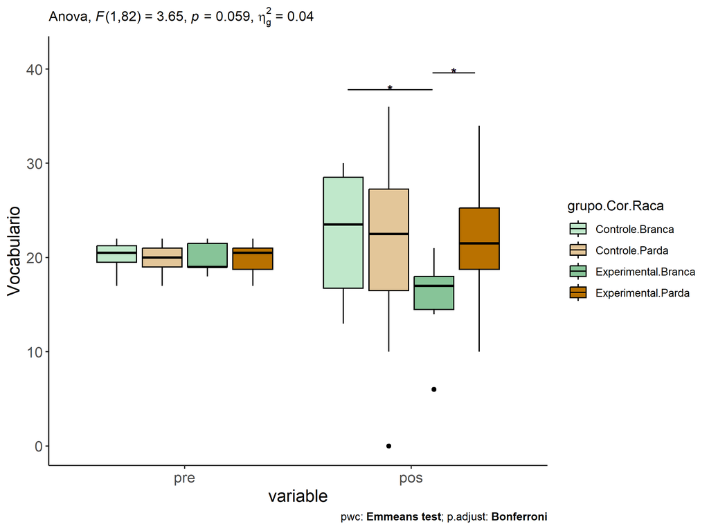

```r
plots[["grupo:Cor.Raca"]] + ggplot2::ylab("Vocabulario") + ggplot2::scale_x_discrete(labels=c('pre', 'pos'))
```

```r
plots <- twoWayAncovaBoxPlots(
  wdat.long, "vocab", c("grupo","Cor.Raca"), aov, pwc.long, pre.post = "time",
  theme = "classic", color = color$prepost)
```

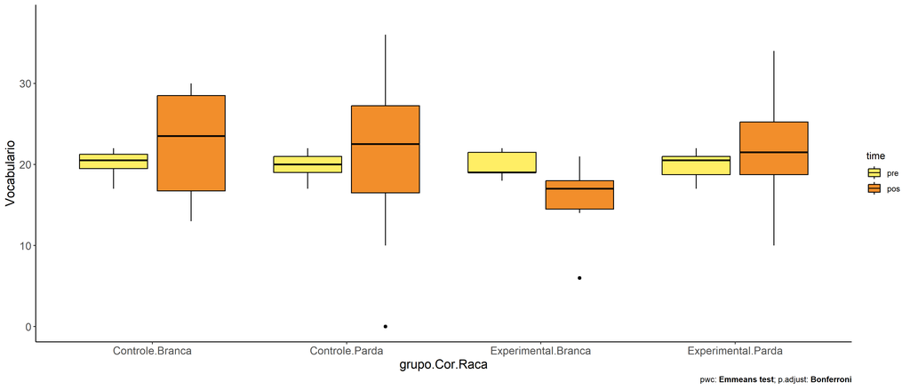

```r
plots[["grupo:Cor.Raca"]] + ggplot2::ylab("Vocabulario")
```

### Checking linearity assumption

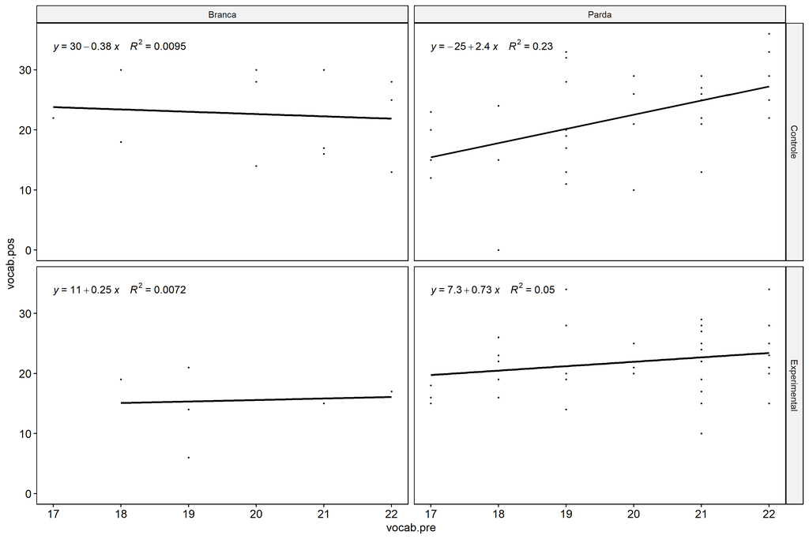

```r
ggscatter(wdat, x = "vocab.pre", y = "vocab.pos", size = 0.5,
          facet.by = c("grupo","Cor.Raca"), add = "reg.line")+
  stat_regline_equation(
    aes(label =  paste(..eq.label.., ..rr.label.., sep = "~~~~"))
  )
```

### Checking normality and homogeneity

```r
res <- augment(lm(vocab.pos ~ vocab.pre + grupo*Cor.Raca, data = wdat))
```

```r
shapiro_test(res$.resid)
```

```
## # A tibble: 1 × 3
##   variable   statistic p.value
##   <chr>          <dbl>   <dbl>
## 1 res$.resid     0.987   0.515
```

```r
levene_test(res, .resid ~ grupo*Cor.Raca)
```

```
## # A tibble: 1 × 4
##     df1   df2 statistic     p
##   <int> <int>     <dbl> <dbl>
## 1     3    83      1.59 0.199
```

# ANCOVA and Pairwise for two factors **grupo:Serie**

## Without remove non-normal data

```r
pdat = remove_group_data(dat[!is.na(dat[["grupo"]]) & !is.na(dat[["Serie"]]),], "vocab.pos", c("grupo","Serie"))

pdat.long <- rbind(pdat[,c("id","grupo","Serie")], pdat[,c("id","grupo","Serie")])
pdat.long[["time"]] <- c(rep("pre", nrow(pdat)), rep("pos", nrow(pdat)))
pdat.long[["time"]] <- factor(pdat.long[["time"]], c("pre","pos"))
pdat.long[["vocab"]] <- c(pdat[["vocab.pre"]], pdat[["vocab.pos"]])

aov = anova_test(pdat, vocab.pos ~ vocab.pre + grupo*Serie)
laov[["grupo:Serie"]] <- get_anova_table(aov)
```

```r
pwcs <- list()
pwcs[["Serie"]] <- emmeans_test(
  group_by(pdat, grupo), vocab.pos ~ Serie,
  covariate = vocab.pre, p.adjust.method = "bonferroni")
pwcs[["grupo"]] <- emmeans_test(
  group_by(pdat, Serie), vocab.pos ~ grupo,
  covariate = vocab.pre, p.adjust.method = "bonferroni")

pwc <- plyr::rbind.fill(pwcs[["grupo"]], pwcs[["Serie"]])
pwc <- pwc[,c("grupo","Serie", colnames(pwc)[!colnames(pwc) %in% c("grupo","Serie")])]
```

```r
pwc.long <- emmeans_test(dplyr::group_by_at(pdat.long, c("grupo","Serie")),
                         vocab ~ time,
                         p.adjust.method = "bonferroni")
lpwc[["grupo:Serie"]] <- plyr::rbind.fill(pwc, pwc.long)
```

```r
ds <- get.descriptives(pdat, "vocab.pos", c("grupo","Serie"), covar = "vocab.pre")
ds <- merge(ds[ds$variable != "vocab.pre",],
            ds[ds$variable == "vocab.pre", !colnames(ds) %in% c("variable")],
            by = c("grupo","Serie"), all.x = T, suffixes = c("", ".vocab.pre"))
ds <- merge(get_emmeans(pwcs[["grupo"]]), ds, by = c("grupo","Serie"), suffixes = c(".emms", ""))
ds <- ds[,c("grupo","Serie","n","mean.vocab.pre","se.vocab.pre","mean","se","emmean","se.emms")]

colnames(ds) <- c("grupo","Serie", "N", paste0(c("M","SE")," (pre)"),
                  paste0(c("M","SE"), " (unadj)"), paste0(c("M", "SE"), " (adj)"))

lemms[["grupo:Serie"]] <- ds
```

## Computing ANCOVA and PairWise After removing non-normal data (OK)

```r
wdat = pdat

res = residuals(lm(vocab.pos ~ vocab.pre + grupo*Serie, data = wdat))
non.normal = getNonNormal(res, wdat$id, plimit = 0.05)

wdat = wdat[!wdat$id %in% non.normal,]

wdat.long <- rbind(wdat[,c("id","grupo","Serie")], wdat[,c("id","grupo","Serie")])
wdat.long[["time"]] <- c(rep("pre", nrow(wdat)), rep("pos", nrow(wdat)))
wdat.long[["time"]] <- factor(wdat.long[["time"]], c("pre","pos"))
wdat.long[["vocab"]] <- c(wdat[["vocab.pre"]], wdat[["vocab.pos"]])


ldat[["grupo:Serie"]] = wdat

(non.normal)
```

```r
aov = anova_test(wdat, vocab.pos ~ vocab.pre + grupo*Serie)
laov[["grupo:Serie"]] <- merge(get_anova_table(aov), laov[["grupo:Serie"]], by="Effect", suffixes = c("","'"))

(df = get_anova_table(aov))
```

```
## ANOVA Table (type II tests)
##
##        Effect DFn DFd     F     p p<.05   ges
## 1   vocab.pre   1 183 3.741 0.055       0.020
## 2       grupo   1 183 1.444 0.231       0.008
## 3       Serie   3 183 0.321 0.810       0.005
## 4 grupo:Serie   3 183 0.310 0.818       0.005
```

| Effect | DFn | DFd | F | p | p<.05 | ges |
| --- | --- | --- | --- | --- | --- | --- |
| vocab.pre | 1 | 183 | 3.741 | 0.055 |  | 0.020 |
| grupo | 1 | 183 | 1.444 | 0.231 |  | 0.008 |
| Serie | 3 | 183 | 0.321 | 0.810 |  | 0.005 |
| grupo:Serie | 3 | 183 | 0.310 | 0.818 |  | 0.005 |

```r
pwcs <- list()
pwcs[["Serie"]] <- emmeans_test(
  group_by(wdat, grupo), vocab.pos ~ Serie,
  covariate = vocab.pre, p.adjust.method = "bonferroni")
pwcs[["grupo"]] <- emmeans_test(
  group_by(wdat, Serie), vocab.pos ~ grupo,
  covariate = vocab.pre, p.adjust.method = "bonferroni")

pwc <- plyr::rbind.fill(pwcs[["grupo"]], pwcs[["Serie"]])
pwc <- pwc[,c("grupo","Serie", colnames(pwc)[!colnames(pwc) %in% c("grupo","Serie")])]
```

| grupo | Serie | term | .y. | group1 | group2 | df | statistic | p | p.adj | p.adj.signif |
| --- | --- | --- | --- | --- | --- | --- | --- | --- | --- | --- |
|  | 6 ano | vocab.pre*grupo | vocab.pos | Controle | Experimental | 183 | 0.120 | 0.905 | 0.905 | ns |
|  | 7 ano | vocab.pre*grupo | vocab.pos | Controle | Experimental | 183 | 0.961 | 0.338 | 0.338 | ns |
|  | 8 ano | vocab.pre*grupo | vocab.pos | Controle | Experimental | 183 | 0.518 | 0.605 | 0.605 | ns |
|  | 9 ano | vocab.pre*grupo | vocab.pos | Controle | Experimental | 183 | 1.088 | 0.278 | 0.278 | ns |
| Controle |  | vocab.pre*Serie | vocab.pos | 6 ano | 7 ano | 183 | -0.871 | 0.385 | 1.000 | ns |
| Controle |  | vocab.pre*Serie | vocab.pos | 6 ano | 8 ano | 183 | -0.713 | 0.477 | 1.000 | ns |
| Controle |  | vocab.pre*Serie | vocab.pos | 6 ano | 9 ano | 183 | -1.179 | 0.240 | 1.000 | ns |
| Controle |  | vocab.pre*Serie | vocab.pos | 7 ano | 8 ano | 183 | -0.044 | 0.965 | 1.000 | ns |
| Controle |  | vocab.pre*Serie | vocab.pos | 7 ano | 9 ano | 183 | -0.708 | 0.480 | 1.000 | ns |
| Controle |  | vocab.pre*Serie | vocab.pos | 8 ano | 9 ano | 183 | -0.611 | 0.542 | 1.000 | ns |
| Experimental |  | vocab.pre*Serie | vocab.pos | 6 ano | 7 ano | 183 | -0.059 | 0.953 | 1.000 | ns |
| Experimental |  | vocab.pre*Serie | vocab.pos | 6 ano | 8 ano | 183 | -0.341 | 0.733 | 1.000 | ns |
| Experimental |  | vocab.pre*Serie | vocab.pos | 6 ano | 9 ano | 183 | -0.045 | 0.965 | 1.000 | ns |
| Experimental |  | vocab.pre*Serie | vocab.pos | 7 ano | 8 ano | 183 | -0.290 | 0.773 | 1.000 | ns |
| Experimental |  | vocab.pre*Serie | vocab.pos | 7 ano | 9 ano | 183 | -0.002 | 0.998 | 1.000 | ns |
| Experimental |  | vocab.pre*Serie | vocab.pos | 8 ano | 9 ano | 183 | 0.213 | 0.832 | 1.000 | ns |

```r
pwc.long <- emmeans_test(dplyr::group_by_at(wdat.long, c("grupo","Serie")),
                         vocab ~ time,
                         p.adjust.method = "bonferroni")
lpwc[["grupo:Serie"]] <- merge(plyr::rbind.fill(pwc, pwc.long), lpwc[["grupo:Serie"]], by=c("grupo","Serie","term",".y.","group1","group2"), suffixes = c("","'"))
```

| grupo | Serie | term | .y. | group1 | group2 | df | statistic | p | p.adj | p.adj.signif |
| --- | --- | --- | --- | --- | --- | --- | --- | --- | --- | --- |
| Controle | 6 ano | time | vocab | pre | pos | 368 | -1.092 | 0.275 | 0.275 | ns |
| Controle | 7 ano | time | vocab | pre | pos | 368 | -2.188 | 0.029 | 0.029 | * |
| Controle | 8 ano | time | vocab | pre | pos | 368 | -1.542 | 0.124 | 0.124 | ns |
| Controle | 9 ano | time | vocab | pre | pos | 368 | -1.528 | 0.127 | 0.127 | ns |
| Experimental | 6 ano | time | vocab | pre | pos | 368 | -0.717 | 0.474 | 0.474 | ns |
| Experimental | 7 ano | time | vocab | pre | pos | 368 | -0.802 | 0.423 | 0.423 | ns |
| Experimental | 8 ano | time | vocab | pre | pos | 368 | -0.914 | 0.362 | 0.362 | ns |
| Experimental | 9 ano | time | vocab | pre | pos | 368 | -0.225 | 0.822 | 0.822 | ns |

```r
ds <- get.descriptives(wdat, "vocab.pos", c("grupo","Serie"), covar = "vocab.pre")
ds <- merge(ds[ds$variable != "vocab.pre",],
            ds[ds$variable == "vocab.pre", !colnames(ds) %in% c("variable")],
            by = c("grupo","Serie"), all.x = T, suffixes = c("", ".vocab.pre"))
ds <- merge(get_emmeans(pwcs[["grupo"]]), ds, by = c("grupo","Serie"), suffixes = c(".emms", ""))
ds <- ds[,c("grupo","Serie","n","mean.vocab.pre","se.vocab.pre","mean","se","emmean","se.emms")]

colnames(ds) <- c("grupo","Serie", "N", paste0(c("M","SE")," (pre)"),
                  paste0(c("M","SE"), " (unadj)"), paste0(c("M", "SE"), " (adj)"))

lemms[["grupo:Serie"]] <- merge(ds, lemms[["grupo:Serie"]], by=c("grupo","Serie"), suffixes = c("","'"))
```

| grupo | Serie | N | M (pre) | SE (pre) | M (unadj) | SE (unadj) | M (adj) | SE (adj) |
| --- | --- | --- | --- | --- | --- | --- | --- | --- |
| Controle | 6 ano | 31 | 19.226 | 0.324 | 20.484 | 0.911 | 20.795 | 1.117 |
| Controle | 7 ano | 35 | 19.686 | 0.255 | 22.057 | 1.031 | 22.122 | 1.041 |
| Controle | 8 ano | 14 | 19.286 | 0.412 | 21.929 | 2.979 | 22.207 | 1.651 |
| Controle | 9 ano | 6 | 20.333 | 0.615 | 24.333 | 2.155 | 24.052 | 2.516 |
| Experimental | 6 ano | 32 | 19.781 | 0.307 | 20.594 | 1.022 | 20.608 | 1.088 |
| Experimental | 7 ano | 34 | 19.824 | 0.282 | 20.706 | 0.996 | 20.697 | 1.055 |
| Experimental | 8 ano | 28 | 20.321 | 0.300 | 21.429 | 1.056 | 21.154 | 1.172 |
| Experimental | 9 ano | 12 | 20.833 | 0.458 | 21.250 | 1.483 | 20.701 | 1.799 |

### Plots for ancova

```r
plots <- twoWayAncovaPlots(
  wdat, "vocab.pos", c("grupo","Serie"), aov, pwcs, addParam = c("mean_se"),
  font.label.size=10, step.increase=0.05, p.label="p.adj",
  subtitle = which(aov$Effect == "grupo:Serie"))
```

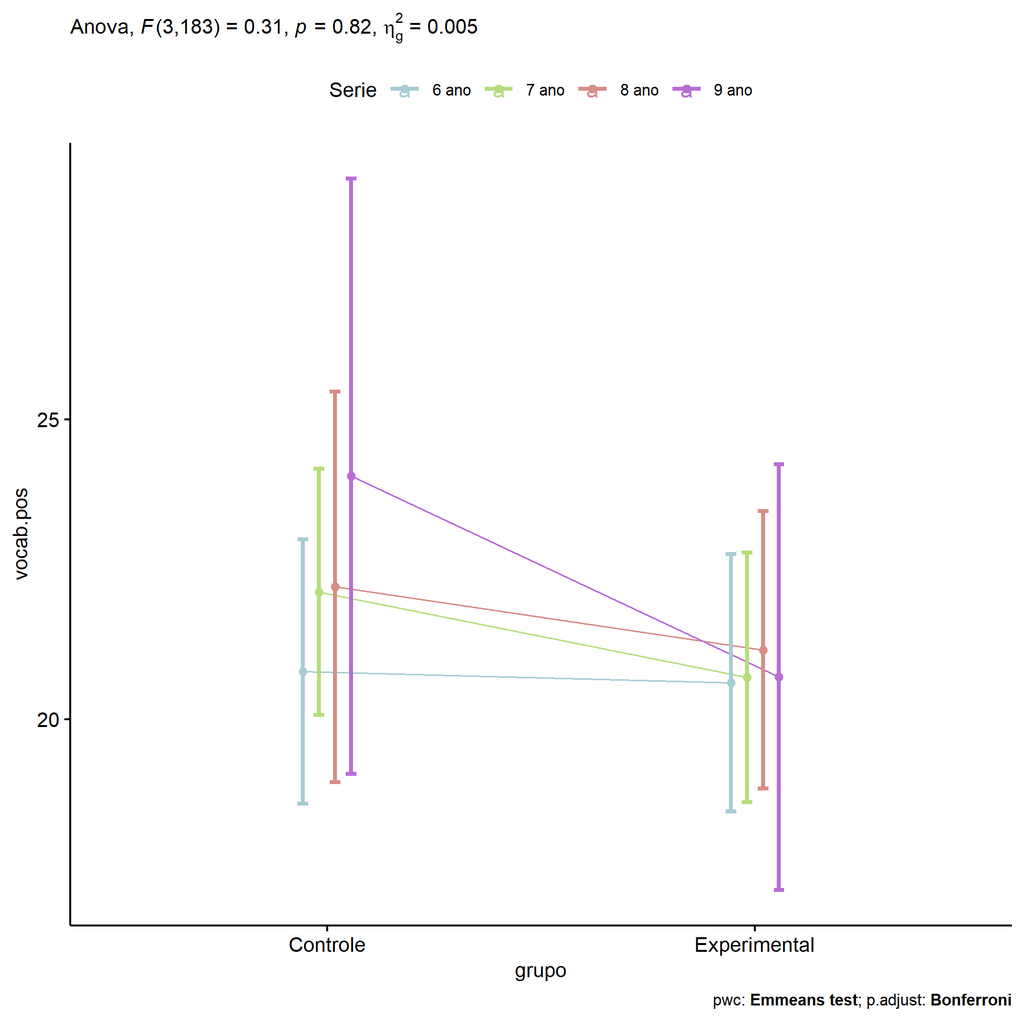

```r
if (!is.null(plots[["grupo"]]))
  plots[["grupo"]] + ggplot2::scale_color_manual(values = color[["Serie"]])
```

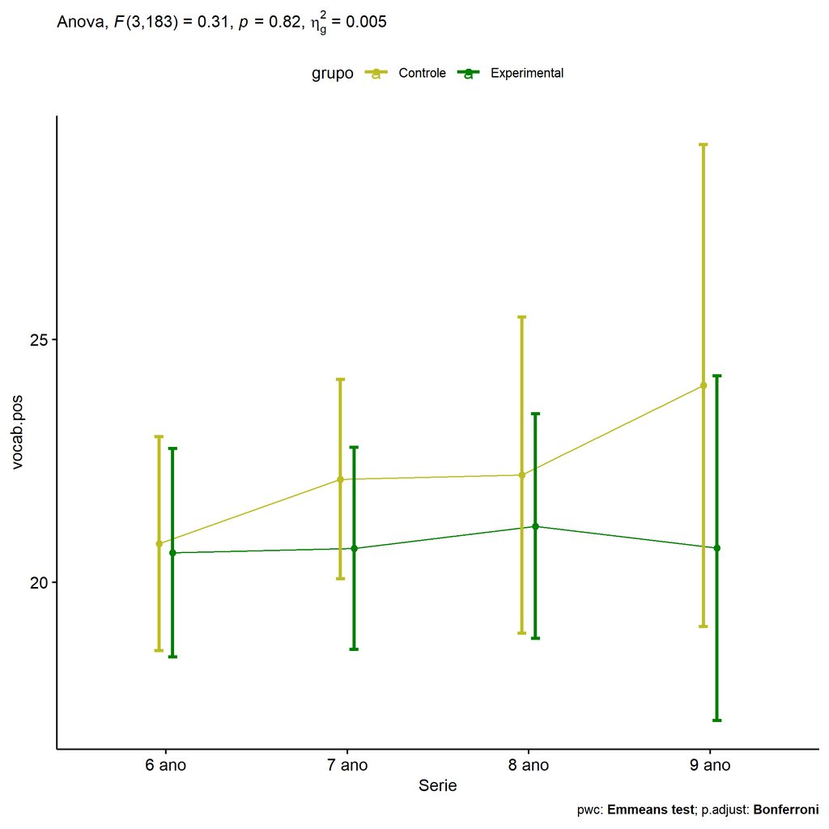

```r
if (!is.null(plots[["Serie"]]))
  plots[["Serie"]] + ggplot2::scale_color_manual(values = color[["grupo"]])
```

```r
plots <- twoWayAncovaBoxPlots(
  wdat, "vocab.pos", c("grupo","Serie"), aov, pwcs, covar = "vocab.pre",
  theme = "classic", color = color[["grupo:Serie"]],
  subtitle = which(aov$Effect == "grupo:Serie"))
```

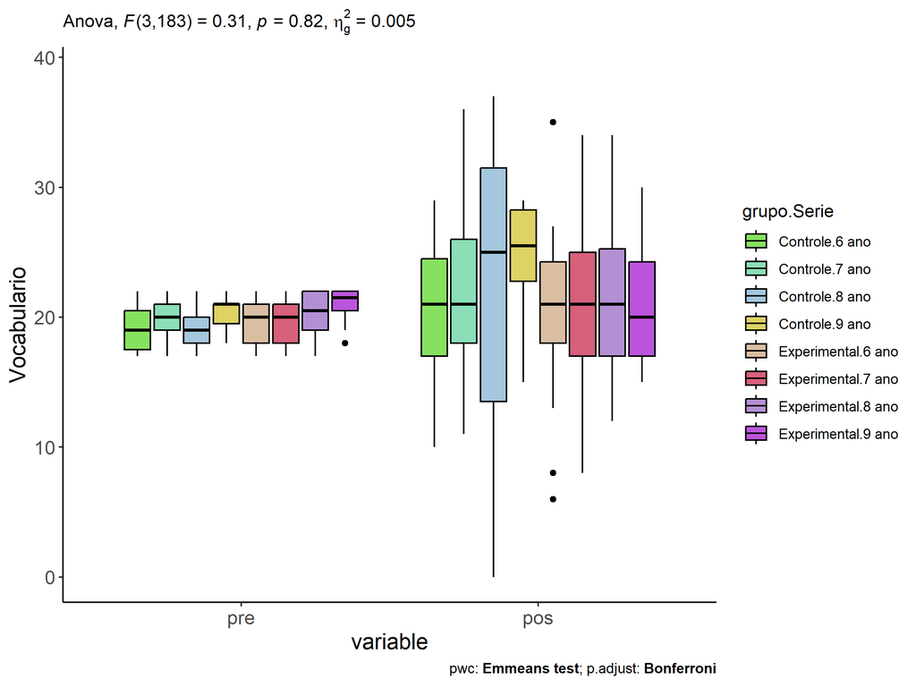

```r
plots[["grupo:Serie"]] + ggplot2::ylab("Vocabulario") + ggplot2::scale_x_discrete(labels=c('pre', 'pos'))
```

```r
plots <- twoWayAncovaBoxPlots(
  wdat.long, "vocab", c("grupo","Serie"), aov, pwc.long, pre.post = "time",
  theme = "classic", color = color$prepost)
```

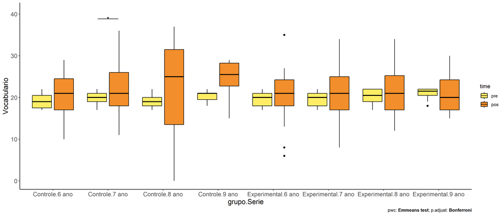

```r
plots[["grupo:Serie"]] + ggplot2::ylab("Vocabulario")
```

### Checking linearity assumption

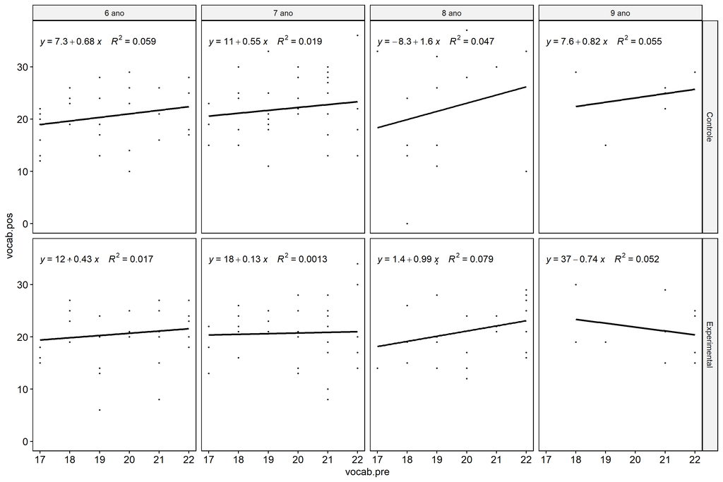

```r
ggscatter(wdat, x = "vocab.pre", y = "vocab.pos", size = 0.5,
          facet.by = c("grupo","Serie"), add = "reg.line")+
  stat_regline_equation(
    aes(label =  paste(..eq.label.., ..rr.label.., sep = "~~~~"))
  )
```

### Checking normality and homogeneity

```r
res <- augment(lm(vocab.pos ~ vocab.pre + grupo*Serie, data = wdat))
```

```r
shapiro_test(res$.resid)
```

```
## # A tibble: 1 × 3
##   variable   statistic p.value
##   <chr>          <dbl>   <dbl>
## 1 res$.resid     0.993   0.469
```

```r
levene_test(res, .resid ~ grupo*Serie)
```

```
## # A tibble: 1 × 4
##     df1   df2 statistic       p
##   <int> <int>     <dbl>   <dbl>
## 1     7   184      3.16 0.00352
```

# Summary of Results

## Descriptive Statistics

```r
df <- get.descriptives(ldat[["grupo"]], c(dv.pre, dv.pos), c("grupo"),
                       include.global = T, symmetry.test = T, normality.test = F)
df <- plyr::rbind.fill(
  df, do.call(plyr::rbind.fill, lapply(lfatores2, FUN = function(f) {
    if (nrow(dat) > 0 && sum(!is.na(unique(dat[[f]]))) > 1)
      get.descriptives(ldat[[paste0("grupo:",f)]], c(dv.pre,dv.pos), c("grupo", f),
                       symmetry.test = T, normality.test = F)
    }))
)
(df <- df[,c(fatores1[fatores1 %in% colnames(df)],"variable",
             colnames(df)[!colnames(df) %in% c(fatores1,"variable")])])
```

```
##           grupo Sexo   Zona Cor.Raca Serie  variable   n   mean median min max     sd    se    ci   iqr symmetry
## 1      Controle <NA>   <NA>     <NA>  <NA> vocab.pre  86 19.500   19.0  17  22  1.629 0.176 0.349  3.00      YES
## 2  Experimental <NA>   <NA>     <NA>  <NA> vocab.pre 106 20.057   20.0  17  22  1.667 0.162 0.321  3.00      YES
## 3          <NA> <NA>   <NA>     <NA>  <NA> vocab.pre 192 19.807   20.0  17  22  1.669 0.120 0.238  3.00      YES
## 4      Controle <NA>   <NA>     <NA>  <NA> vocab.pos  86 21.628   21.5   0  37  6.758 0.729 1.449  9.00      YES
## 5  Experimental <NA>   <NA>     <NA>  <NA> vocab.pos 106 20.925   21.0   6  35  5.602 0.544 1.079  8.00      YES
## 6          <NA> <NA>   <NA>     <NA>  <NA> vocab.pos 192 21.240   21.0   0  37  6.140 0.443 0.874  8.00      YES
## 7      Controle    F   <NA>     <NA>  <NA> vocab.pre  39 19.513   19.0  17  22  1.620 0.259 0.525  3.00      YES
## 8      Controle    M   <NA>     <NA>  <NA> vocab.pre  47 19.489   20.0  17  22  1.653 0.241 0.485  3.00      YES
## 9  Experimental    F   <NA>     <NA>  <NA> vocab.pre  49 19.939   20.0  17  22  1.676 0.239 0.481  3.00      YES
## 10 Experimental    M   <NA>     <NA>  <NA> vocab.pre  57 20.158   20.0  17  22  1.667 0.221 0.442  3.00      YES
## 11     Controle    F   <NA>     <NA>  <NA> vocab.pos  39 21.897   22.0   0  32  6.189 0.991 2.006  7.00       NO
## 12     Controle    M   <NA>     <NA>  <NA> vocab.pos  47 21.404   21.0  10  37  7.255 1.058 2.130 11.00      YES
## 13 Experimental    F   <NA>     <NA>  <NA> vocab.pos  49 22.306   23.0   8  34  4.993 0.713 1.434  6.00      YES
## 14 Experimental    M   <NA>     <NA>  <NA> vocab.pos  57 19.737   20.0   6  35  5.863 0.777 1.556  8.00      YES
```

[output cut: 79 more lines]

| grupo | Sexo | Zona | Cor.Raca | Serie | variable | n | mean | median | min | max | sd | se | ci | iqr | symmetry | skewness | kurtosis |
| --- | --- | --- | --- | --- | --- | --- | --- | --- | --- | --- | --- | --- | --- | --- | --- | --- | --- |
| Controle |  |  |  |  | vocab.pre | 86 | 19.500 | 19.0 | 17 | 22 | 1.629 | 0.176 | 0.349 | 3.00 | YES | 0.016 | -1.197 |
| Experimental |  |  |  |  | vocab.pre | 106 | 20.057 | 20.0 | 17 | 22 | 1.667 | 0.162 | 0.321 | 3.00 | YES | -0.333 | -1.225 |
|  |  |  |  |  | vocab.pre | 192 | 19.807 | 20.0 | 17 | 22 | 1.669 | 0.120 | 0.238 | 3.00 | YES | -0.166 | -1.247 |
| Controle |  |  |  |  | vocab.pos | 86 | 21.628 | 21.5 | 0 | 37 | 6.758 | 0.729 | 1.449 | 9.00 | YES | -0.189 | 0.031 |
| Experimental |  |  |  |  | vocab.pos | 106 | 20.925 | 21.0 | 6 | 35 | 5.602 | 0.544 | 1.079 | 8.00 | YES | -0.073 | -0.068 |
|  |  |  |  |  | vocab.pos | 192 | 21.240 | 21.0 | 0 | 37 | 6.140 | 0.443 | 0.874 | 8.00 | YES | -0.112 | 0.112 |
| Controle | F |  |  |  | vocab.pre | 39 | 19.513 | 19.0 | 17 | 22 | 1.620 | 0.259 | 0.525 | 3.00 | YES | 0.140 | -1.265 |
| Controle | M |  |  |  | vocab.pre | 47 | 19.489 | 20.0 | 17 | 22 | 1.653 | 0.241 | 0.485 | 3.00 | YES | -0.081 | -1.226 |
| Experimental | F |  |  |  | vocab.pre | 49 | 19.939 | 20.0 | 17 | 22 | 1.676 | 0.239 | 0.481 | 3.00 | YES | -0.192 | -1.414 |
| Experimental | M |  |  |  | vocab.pre | 57 | 20.158 | 20.0 | 17 | 22 | 1.667 | 0.221 | 0.442 | 3.00 | YES | -0.451 | -1.080 |
| Controle | F |  |  |  | vocab.pos | 39 | 21.897 | 22.0 | 0 | 32 | 6.189 | 0.991 | 2.006 | 7.00 | NO | -0.947 | 1.938 |
| Controle | M |  |  |  | vocab.pos | 47 | 21.404 | 21.0 | 10 | 37 | 7.255 | 1.058 | 2.130 | 11.00 | YES | 0.232 | -0.904 |
| Experimental | F |  |  |  | vocab.pos | 49 | 22.306 | 23.0 | 8 | 34 | 4.993 | 0.713 | 1.434 | 6.00 | YES | -0.439 | 0.188 |
| Experimental | M |  |  |  | vocab.pos | 57 | 19.737 | 20.0 | 6 | 35 | 5.863 | 0.777 | 1.556 | 8.00 | YES | 0.276 | 0.097 |
| Controle |  | Rural |  |  | vocab.pre | 41 | 19.366 | 19.0 | 17 | 22 | 1.699 | 0.265 | 0.536 | 3.00 | YES | 0.061 | -1.252 |
| Controle |  | Urbana |  |  | vocab.pre | 23 | 20.043 | 21.0 | 17 | 22 | 1.581 | 0.330 | 0.683 | 2.00 | YES | -0.464 | -1.065 |
| Experimental |  | Rural |  |  | vocab.pre | 50 | 20.100 | 21.0 | 17 | 22 | 1.693 | 0.239 | 0.481 | 3.00 | YES | -0.376 | -1.275 |
| Experimental |  | Urbana |  |  | vocab.pre | 27 | 19.963 | 20.0 | 17 | 22 | 1.629 | 0.313 | 0.644 | 2.00 | NO | -0.509 | -0.980 |
| Controle |  | Rural |  |  | vocab.pos | 41 | 22.049 | 23.0 | 10 | 36 | 6.834 | 1.067 | 2.157 | 10.00 | YES | 0.077 | -1.038 |
| Controle |  | Urbana |  |  | vocab.pos | 23 | 23.174 | 22.0 | 13 | 30 | 4.217 | 0.879 | 1.824 | 4.50 | YES | -0.182 | -0.401 |
| Experimental |  | Rural |  |  | vocab.pos | 50 | 20.740 | 21.0 | 6 | 34 | 5.138 | 0.727 | 1.460 | 7.00 | YES | -0.267 | 0.434 |
| Experimental |  | Urbana |  |  | vocab.pos | 27 | 21.148 | 21.0 | 8 | 34 | 5.641 | 1.086 | 2.232 | 7.50 | YES | -0.078 | -0.148 |
| Controle |  |  | Branca |  | vocab.pre | 12 | 20.167 | 20.5 | 17 | 22 | 1.697 | 0.490 | 1.078 | 1.75 | NO | -0.544 | -1.190 |
| Controle |  |  | Parda |  | vocab.pre | 32 | 19.750 | 20.0 | 17 | 22 | 1.626 | 0.288 | 0.586 | 2.00 | YES | -0.218 | -1.182 |
| Experimental |  |  | Branca |  | vocab.pre | 7 | 20.000 | 19.0 | 18 | 22 | 1.633 | 0.617 | 1.510 | 2.50 | YES | 0.197 | -1.955 |
| Experimental |  |  | Parda |  | vocab.pre | 36 | 20.000 | 20.5 | 17 | 22 | 1.673 | 0.279 | 0.566 | 2.25 | YES | -0.356 | -1.292 |
| Controle |  |  | Branca |  | vocab.pos | 12 | 22.583 | 23.5 | 13 | 30 | 6.680 | 1.928 | 4.245 | 11.75 | YES | -0.143 | -1.829 |
| Controle |  |  | Parda |  | vocab.pos | 32 | 21.938 | 22.5 | 0 | 36 | 7.971 | 1.409 | 2.874 | 10.75 | NO | -0.532 | -0.029 |
| Experimental |  |  | Branca |  | vocab.pos | 7 | 15.571 | 17.0 | 6 | 21 | 4.826 | 1.824 | 4.463 | 3.50 | NO | -0.858 | -0.520 |
| Experimental |  |  | Parda |  | vocab.pos | 36 | 21.944 | 21.5 | 10 | 34 | 5.487 | 0.915 | 1.857 | 6.50 | YES | 0.167 | -0.388 |
| Controle |  |  |  | 6 ano | vocab.pre | 31 | 19.226 | 19.0 | 17 | 22 | 1.802 | 0.324 | 0.661 | 3.00 | YES | 0.169 | -1.368 |
| Controle |  |  |  | 7 ano | vocab.pre | 35 | 19.686 | 20.0 | 17 | 22 | 1.510 | 0.255 | 0.519 | 2.00 | YES | -0.123 | -1.132 |
| Controle |  |  |  | 8 ano | vocab.pre | 14 | 19.286 | 19.0 | 17 | 22 | 1.541 | 0.412 | 0.890 | 2.00 | YES | 0.493 | -1.023 |
| Controle |  |  |  | 9 ano | vocab.pre | 6 | 20.333 | 21.0 | 18 | 22 | 1.506 | 0.615 | 1.580 | 1.50 | YES | -0.467 | -1.666 |
| Experimental |  |  |  | 6 ano | vocab.pre | 32 | 19.781 | 20.0 | 17 | 22 | 1.736 | 0.307 | 0.626 | 3.00 | YES | -0.175 | -1.369 |
| Experimental |  |  |  | 7 ano | vocab.pre | 34 | 19.824 | 20.0 | 17 | 22 | 1.642 | 0.282 | 0.573 | 3.00 | YES | -0.244 | -1.302 |
| Experimental |  |  |  | 8 ano | vocab.pre | 28 | 20.321 | 20.5 | 17 | 22 | 1.588 | 0.300 | 0.616 | 3.00 | YES | -0.353 | -1.275 |
| Experimental |  |  |  | 9 ano | vocab.pre | 12 | 20.833 | 21.5 | 18 | 22 | 1.586 | 0.458 | 1.008 | 1.50 | NO | -0.880 | -1.007 |
| Controle |  |  |  | 6 ano | vocab.pos | 31 | 20.484 | 21.0 | 10 | 29 | 5.072 | 0.911 | 1.860 | 7.50 | YES | -0.219 | -0.948 |
| Controle |  |  |  | 7 ano | vocab.pos | 35 | 22.057 | 21.0 | 11 | 36 | 6.097 | 1.031 | 2.094 | 8.00 | YES | 0.223 | -0.692 |
| Controle |  |  |  | 8 ano | vocab.pos | 14 | 21.929 | 25.0 | 0 | 37 | 11.146 | 2.979 | 6.435 | 18.00 | YES | -0.358 | -1.266 |
| Controle |  |  |  | 9 ano | vocab.pos | 6 | 24.333 | 25.5 | 15 | 29 | 5.279 | 2.155 | 5.540 | 5.50 | NO | -0.700 | -1.160 |
| Experimental |  |  |  | 6 ano | vocab.pos | 32 | 20.594 | 21.0 | 6 | 35 | 5.780 | 1.022 | 2.084 | 6.25 | YES | -0.336 | 0.592 |
| Experimental |  |  |  | 7 ano | vocab.pos | 34 | 20.706 | 21.0 | 8 | 34 | 5.808 | 0.996 | 2.026 | 8.00 | YES | -0.083 | -0.429 |
| Experimental |  |  |  | 8 ano | vocab.pos | 28 | 21.429 | 21.0 | 12 | 34 | 5.587 | 1.056 | 2.166 | 8.25 | YES | 0.183 | -0.927 |
| Experimental |  |  |  | 9 ano | vocab.pos | 12 | 21.250 | 20.0 | 15 | 30 | 5.137 | 1.483 | 3.264 | 7.25 | YES | 0.347 | -1.380 |

## ANCOVA Table Comparison

```r
df <- do.call(plyr::rbind.fill, laov)
(df <- df[!duplicated(df$Effect),])
```

```
##            Effect DFn DFd     F     p p<.05      ges DFn' DFd'    F'    p' p<.05'     ges'
## 1           grupo   1 189 1.316 0.253       7.00e-03    1  189 1.316 0.253        7.00e-03
## 2       vocab.pre   1 189 4.743 0.031     * 2.40e-02    1  189 4.743 0.031      * 2.40e-02
## 4      grupo:Sexo   1 187 1.600 0.207       8.00e-03    1  187 1.600 0.207        8.00e-03
## 5            Sexo   1 187 3.814 0.052       2.00e-02    1  187 3.814 0.052        2.00e-02
## 8      grupo:Zona   1 136 0.007 0.935       4.84e-05    1  136 0.007 0.935        4.84e-05
## 10           Zona   1 136 0.343 0.559       3.00e-03    1  136 0.343 0.559        3.00e-03
## 11       Cor.Raca   1  82 2.154 0.146       2.60e-02    1   82 2.154 0.146        2.60e-02
## 13 grupo:Cor.Raca   1  82 3.655 0.059       4.30e-02    1   82 3.655 0.059        4.30e-02
## 16    grupo:Serie   3 183 0.310 0.818       5.00e-03    3  183 0.310 0.818        5.00e-03
## 17          Serie   3 183 0.321 0.810       5.00e-03    3  183 0.321 0.810        5.00e-03
```

|  | Effect | DFn | DFd | F | p | p<.05 | ges | DFn’ | DFd’ | F’ | p’ | p<.05’ | ges’ |
| --- | --- | --- | --- | --- | --- | --- | --- | --- | --- | --- | --- | --- | --- |
| 1 | grupo | 1 | 189 | 1.316 | 0.253 |  | 0.007 | 1 | 189 | 1.316 | 0.253 |  | 0.007 |
| 2 | vocab.pre | 1 | 189 | 4.743 | 0.031 | * | 0.024 | 1 | 189 | 4.743 | 0.031 | * | 0.024 |
| 4 | grupo:Sexo | 1 | 187 | 1.600 | 0.207 |  | 0.008 | 1 | 187 | 1.600 | 0.207 |  | 0.008 |
| 5 | Sexo | 1 | 187 | 3.814 | 0.052 |  | 0.020 | 1 | 187 | 3.814 | 0.052 |  | 0.020 |
| 8 | grupo:Zona | 1 | 136 | 0.007 | 0.935 |  | 0.000 | 1 | 136 | 0.007 | 0.935 |  | 0.000 |
| 10 | Zona | 1 | 136 | 0.343 | 0.559 |  | 0.003 | 1 | 136 | 0.343 | 0.559 |  | 0.003 |
| 11 | Cor.Raca | 1 | 82 | 2.154 | 0.146 |  | 0.026 | 1 | 82 | 2.154 | 0.146 |  | 0.026 |
| 13 | grupo:Cor.Raca | 1 | 82 | 3.655 | 0.059 |  | 0.043 | 1 | 82 | 3.655 | 0.059 |  | 0.043 |
| 16 | grupo:Serie | 3 | 183 | 0.310 | 0.818 |  | 0.005 | 3 | 183 | 0.310 | 0.818 |  | 0.005 |
| 17 | Serie | 3 | 183 | 0.321 | 0.810 |  | 0.005 | 3 | 183 | 0.321 | 0.810 |  | 0.005 |

## PairWise Table Comparison

```r
df <- do.call(plyr::rbind.fill, lpwc)
df <- df[,c(names(lfatores), names(df)[!names(df) %in% c(names(lfatores),"term",".y.")])]
```

| grupo | Sexo | Zona | Cor.Raca | Serie | group1 | group2 | df | statistic | p | p.adj | p.adj.signif | df’ | statistic’ | p’ | p.adj’ | p.adj.signif’ |
| --- | --- | --- | --- | --- | --- | --- | --- | --- | --- | --- | --- | --- | --- | --- | --- | --- |
| Controle |  |  |  |  | pre | pos | 380 | -3.101 | 0.002 | 0.002 | ** | 380 | -3.101 | 0.002 | 0.002 | ** |
| Experimental |  |  |  |  | pre | pos | 380 | -1.404 | 0.161 | 0.161 | ns | 380 | -1.404 | 0.161 | 0.161 | ns |
|  |  |  |  |  | Controle | Experimental | 189 | 1.147 | 0.253 | 0.253 | ns | 189 | 1.147 | 0.253 | 0.253 | ns |
| Controle | F |  |  |  | pre | pos | 376 | -2.356 | 0.019 | 0.019 | * | 376 | -2.356 | 0.019 | 0.019 | * |
| Controle | M |  |  |  | pre | pos | 376 | -2.076 | 0.039 | 0.039 | * | 376 | -2.076 | 0.039 | 0.039 | * |
| Controle |  |  |  |  | F | M | 187 | 0.366 | 0.714 | 0.714 | ns | 187 | 0.366 | 0.714 | 0.714 | ns |
| Experimental | F |  |  |  | pre | pos | 376 | -2.621 | 0.009 | 0.009 | ** | 376 | -2.621 | 0.009 | 0.009 | ** |
| Experimental | M |  |  |  | pre | pos | 376 | 0.503 | 0.615 | 0.615 | ns | 376 | 0.503 | 0.615 | 0.615 | ns |
| Experimental |  |  |  |  | F | M | 187 | 2.298 | 0.023 | 0.023 | * | 187 | 2.298 | 0.023 | 0.023 | * |
|  | F |  |  |  | Controle | Experimental | 187 | -0.114 | 0.910 | 0.910 | ns | 187 | -0.114 | 0.910 | 0.910 | ns |
|  | M |  |  |  | Controle | Experimental | 187 | 1.728 | 0.086 | 0.086 | ns | 187 | 1.728 | 0.086 | 0.086 | ns |
| Controle |  |  |  |  | Rural | Urbana | 136 | -0.453 | 0.651 | 0.651 | ns | 136 | -0.453 | 0.651 | 0.651 | ns |
| Controle |  | Rural |  |  | pre | pos | 274 | -2.914 | 0.004 | 0.004 | ** | 274 | -2.914 | 0.004 | 0.004 | ** |
| Controle |  | Urbana |  |  | pre | pos | 274 | -2.547 | 0.011 | 0.011 | * | 274 | -2.547 | 0.011 | 0.011 | * |
| Experimental |  |  |  |  | Rural | Urbana | 136 | -0.378 | 0.706 | 0.706 | ns | 136 | -0.378 | 0.706 | 0.706 | ns |
| Experimental |  | Rural |  |  | pre | pos | 274 | -0.768 | 0.443 | 0.443 | ns | 274 | -0.768 | 0.443 | 0.443 | ns |
| Experimental |  | Urbana |  |  | pre | pos | 274 | -1.045 | 0.297 | 0.297 | ns | 274 | -1.045 | 0.297 | 0.297 | ns |
|  |  | Rural |  |  | Controle | Experimental | 136 | 1.521 | 0.130 | 0.130 | ns | 136 | 1.521 | 0.130 | 0.130 | ns |
|  |  | Urbana |  |  | Controle | Experimental | 136 | 1.249 | 0.214 | 0.214 | ns | 136 | 1.249 | 0.214 | 0.214 | ns |
| Controle |  |  | Branca |  | pre | pos | 166 | -1.224 | 0.223 | 0.223 | ns | 166 | -1.224 | 0.223 | 0.223 | ns |
| Controle |  |  |  |  | Branca | Parda | 82 | 0.080 | 0.936 | 0.936 | ns | 82 | 0.080 | 0.936 | 0.936 | ns |
| Controle |  |  | Parda |  | pre | pos | 166 | -1.809 | 0.072 | 0.072 | ns | 166 | -1.809 | 0.072 | 0.072 | ns |
| Experimental |  |  | Branca |  | pre | pos | 166 | 1.713 | 0.089 | 0.089 | ns | 166 | 1.713 | 0.089 | 0.089 | ns |
| Experimental |  |  |  |  | Branca | Parda | 82 | -2.409 | 0.018 | 0.018 | * | 82 | -2.409 | 0.018 | 0.018 | * |
| Experimental |  |  | Parda |  | pre | pos | 166 | -1.706 | 0.090 | 0.090 | ns | 166 | -1.706 | 0.090 | 0.090 | ns |
|  |  |  | Branca |  | Controle | Experimental | 82 | 2.240 | 0.028 | 0.028 | * | 82 | 2.240 | 0.028 | 0.028 | * |
|  |  |  | Parda |  | Controle | Experimental | 82 | 0.177 | 0.860 | 0.860 | ns | 82 | 0.177 | 0.860 | 0.860 | ns |
| Controle |  |  |  | 6 ano | pre | pos | 368 | -1.092 | 0.275 | 0.275 | ns | 368 | -1.092 | 0.275 | 0.275 | ns |
| Controle |  |  |  | 7 ano | pre | pos | 368 | -2.188 | 0.029 | 0.029 | * | 368 | -2.188 | 0.029 | 0.029 | * |
| Controle |  |  |  | 8 ano | pre | pos | 368 | -1.542 | 0.124 | 0.124 | ns | 368 | -1.542 | 0.124 | 0.124 | ns |
| Controle |  |  |  | 9 ano | pre | pos | 368 | -1.528 | 0.127 | 0.127 | ns | 368 | -1.528 | 0.127 | 0.127 | ns |
| Controle |  |  |  |  | 6 ano | 7 ano | 183 | -0.871 | 0.385 | 1.000 | ns | 183 | -0.871 | 0.385 | 1.000 | ns |
| Controle |  |  |  |  | 6 ano | 8 ano | 183 | -0.713 | 0.477 | 1.000 | ns | 183 | -0.713 | 0.477 | 1.000 | ns |
| Controle |  |  |  |  | 6 ano | 9 ano | 183 | -1.179 | 0.240 | 1.000 | ns | 183 | -1.179 | 0.240 | 1.000 | ns |
| Controle |  |  |  |  | 7 ano | 8 ano | 183 | -0.044 | 0.965 | 1.000 | ns | 183 | -0.044 | 0.965 | 1.000 | ns |
| Controle |  |  |  |  | 7 ano | 9 ano | 183 | -0.708 | 0.480 | 1.000 | ns | 183 | -0.708 | 0.480 | 1.000 | ns |
| Controle |  |  |  |  | 8 ano | 9 ano | 183 | -0.611 | 0.542 | 1.000 | ns | 183 | -0.611 | 0.542 | 1.000 | ns |
| Experimental |  |  |  | 6 ano | pre | pos | 368 | -0.717 | 0.474 | 0.474 | ns | 368 | -0.717 | 0.474 | 0.474 | ns |
| Experimental |  |  |  | 7 ano | pre | pos | 368 | -0.802 | 0.423 | 0.423 | ns | 368 | -0.802 | 0.423 | 0.423 | ns |
| Experimental |  |  |  | 8 ano | pre | pos | 368 | -0.914 | 0.362 | 0.362 | ns | 368 | -0.914 | 0.362 | 0.362 | ns |
| Experimental |  |  |  | 9 ano | pre | pos | 368 | -0.225 | 0.822 | 0.822 | ns | 368 | -0.225 | 0.822 | 0.822 | ns |
| Experimental |  |  |  |  | 6 ano | 7 ano | 183 | -0.059 | 0.953 | 1.000 | ns | 183 | -0.059 | 0.953 | 1.000 | ns |
| Experimental |  |  |  |  | 6 ano | 8 ano | 183 | -0.341 | 0.733 | 1.000 | ns | 183 | -0.341 | 0.733 | 1.000 | ns |
| Experimental |  |  |  |  | 6 ano | 9 ano | 183 | -0.045 | 0.965 | 1.000 | ns | 183 | -0.045 | 0.965 | 1.000 | ns |
| Experimental |  |  |  |  | 7 ano | 8 ano | 183 | -0.290 | 0.773 | 1.000 | ns | 183 | -0.290 | 0.773 | 1.000 | ns |
| Experimental |  |  |  |  | 7 ano | 9 ano | 183 | -0.002 | 0.998 | 1.000 | ns | 183 | -0.002 | 0.998 | 1.000 | ns |
| Experimental |  |  |  |  | 8 ano | 9 ano | 183 | 0.213 | 0.832 | 1.000 | ns | 183 | 0.213 | 0.832 | 1.000 | ns |
|  |  |  |  | 6 ano | Controle | Experimental | 183 | 0.120 | 0.905 | 0.905 | ns | 183 | 0.120 | 0.905 | 0.905 | ns |
|  |  |  |  | 7 ano | Controle | Experimental | 183 | 0.961 | 0.338 | 0.338 | ns | 183 | 0.961 | 0.338 | 0.338 | ns |
|  |  |  |  | 8 ano | Controle | Experimental | 183 | 0.518 | 0.605 | 0.605 | ns | 183 | 0.518 | 0.605 | 0.605 | ns |
|  |  |  |  | 9 ano | Controle | Experimental | 183 | 1.088 | 0.278 | 0.278 | ns | 183 | 1.088 | 0.278 | 0.278 | ns |

## EMMS Table Comparison

```r
df <- do.call(plyr::rbind.fill, lemms)
df[["N-N'"]] <- df[["N"]] - df[["N'"]]
df <- df[,c(names(lfatores), names(df)[!names(df) %in% names(lfatores)])]
```

| grupo | Sexo | Zona | Cor.Raca | Serie | N | M (pre) | SE (pre) | M (unadj) | SE (unadj) | M (adj) | SE (adj) | N’ | M (pre)’ | SE (pre)’ | M (unadj)’ | SE (unadj)’ | M (adj)’ | SE (adj)’ | N-N’ |
| --- | --- | --- | --- | --- | --- | --- | --- | --- | --- | --- | --- | --- | --- | --- | --- | --- | --- | --- | --- |
| Controle |  |  |  |  | 86 | 19.500 | 0.176 | 21.628 | 0.729 | 21.807 | 0.661 | 86 | 19.500 | 0.176 | 21.628 | 0.729 | 21.807 | 0.661 | 0 |
| Experimental |  |  |  |  | 106 | 20.057 | 0.162 | 20.925 | 0.544 | 20.779 | 0.595 | 106 | 20.057 | 0.162 | 20.925 | 0.544 | 20.779 | 0.595 | 0 |
| Controle | F |  |  |  | 39 | 19.513 | 0.259 | 21.897 | 0.991 | 22.078 | 0.969 | 39 | 19.513 | 0.259 | 21.897 | 0.991 | 22.078 | 0.969 | 0 |
| Controle | M |  |  |  | 47 | 19.489 | 0.241 | 21.404 | 1.058 | 21.599 | 0.884 | 47 | 19.489 | 0.241 | 21.404 | 1.058 | 21.599 | 0.884 | 0 |
| Experimental | F |  |  |  | 49 | 19.939 | 0.239 | 22.306 | 0.713 | 22.226 | 0.862 | 49 | 19.939 | 0.239 | 22.306 | 0.713 | 22.226 | 0.862 | 0 |
| Experimental | M |  |  |  | 57 | 20.158 | 0.221 | 19.737 | 0.777 | 19.522 | 0.804 | 57 | 20.158 | 0.221 | 19.737 | 0.777 | 19.522 | 0.804 | 0 |
| Controle |  | Rural |  |  | 41 | 19.366 | 0.265 | 22.049 | 1.067 | 22.380 | 0.879 | 41 | 19.366 | 0.265 | 22.049 | 1.067 | 22.380 | 0.879 | 0 |
| Controle |  | Urbana |  |  | 23 | 20.043 | 0.330 | 23.174 | 0.879 | 23.042 | 1.160 | 23 | 20.043 | 0.330 | 23.174 | 0.879 | 23.042 | 1.160 | 0 |
| Experimental |  | Rural |  |  | 50 | 20.100 | 0.239 | 20.740 | 0.727 | 20.570 | 0.789 | 50 | 20.100 | 0.239 | 20.740 | 0.727 | 20.570 | 0.789 | 0 |
| Experimental |  | Urbana |  |  | 27 | 19.963 | 0.313 | 21.148 | 1.086 | 21.072 | 1.070 | 27 | 19.963 | 0.313 | 21.148 | 1.086 | 21.072 | 1.070 | 0 |
| Controle |  |  | Branca |  | 12 | 20.167 | 0.490 | 22.583 | 1.928 | 22.317 | 1.852 | 12 | 20.167 | 0.490 | 22.583 | 1.928 | 22.317 | 1.852 | 0 |
| Controle |  |  | Parda |  | 32 | 19.750 | 0.288 | 21.938 | 1.409 | 22.142 | 1.135 | 32 | 19.750 | 0.288 | 21.938 | 1.409 | 22.142 | 1.135 | 0 |
| Experimental |  |  | Branca |  | 7 | 20.000 | 0.617 | 15.571 | 1.824 | 15.493 | 2.421 | 7 | 20.000 | 0.617 | 15.571 | 1.824 | 15.493 | 2.421 | 0 |
| Experimental |  |  | Parda |  | 36 | 20.000 | 0.279 | 21.944 | 0.915 | 21.866 | 1.068 | 36 | 20.000 | 0.279 | 21.944 | 0.915 | 21.866 | 1.068 | 0 |
| Controle |  |  |  | 6 ano | 31 | 19.226 | 0.324 | 20.484 | 0.911 | 20.795 | 1.117 | 31 | 19.226 | 0.324 | 20.484 | 0.911 | 20.795 | 1.117 | 0 |
| Controle |  |  |  | 7 ano | 35 | 19.686 | 0.255 | 22.057 | 1.031 | 22.122 | 1.041 | 35 | 19.686 | 0.255 | 22.057 | 1.031 | 22.122 | 1.041 | 0 |
| Controle |  |  |  | 8 ano | 14 | 19.286 | 0.412 | 21.929 | 2.979 | 22.207 | 1.651 | 14 | 19.286 | 0.412 | 21.929 | 2.979 | 22.207 | 1.651 | 0 |
| Controle |  |  |  | 9 ano | 6 | 20.333 | 0.615 | 24.333 | 2.155 | 24.052 | 2.516 | 6 | 20.333 | 0.615 | 24.333 | 2.155 | 24.052 | 2.516 | 0 |
| Experimental |  |  |  | 6 ano | 32 | 19.781 | 0.307 | 20.594 | 1.022 | 20.608 | 1.088 | 32 | 19.781 | 0.307 | 20.594 | 1.022 | 20.608 | 1.088 | 0 |
| Experimental |  |  |  | 7 ano | 34 | 19.824 | 0.282 | 20.706 | 0.996 | 20.697 | 1.055 | 34 | 19.824 | 0.282 | 20.706 | 0.996 | 20.697 | 1.055 | 0 |
| Experimental |  |  |  | 8 ano | 28 | 20.321 | 0.300 | 21.429 | 1.056 | 21.154 | 1.172 | 28 | 20.321 | 0.300 | 21.429 | 1.056 | 21.154 | 1.172 | 0 |
| Experimental |  |  |  | 9 ano | 12 | 20.833 | 0.458 | 21.250 | 1.483 | 20.701 | 1.799 | 12 | 20.833 | 0.458 | 21.250 | 1.483 | 20.701 | 1.799 | 0 |